# Cheatsheet for R

FS24 - Research Beyond the Lab

Author

Affiliation

Sven Prinz

[ETH Zurich](https://ethz.ch/de.html)

Published

June 12, 2024

Abstract

This document includes a bunch of functions that were used during the lecture ‘Research Beyond the Lab - Open Science and Research Methods for a Global Engineer’ in the Spring semester 2024 (https://rbtl-fs24.github.io/website/). Feel free to use it for the exam. No guarantee is given for completeness or correctness.

## Useful stuff

**HELP:** `?<func_name>`

**Generic YAML header:**

```r
---
title: "Title"
subtitle: "Subtitle"
date: today
author:
  - name: "Sven Prinz"
    orcid: 0009-0000-4485-1235
    email: sprinz@ethz.ch
    affiliation:
      - name: ETH Zurich
        url: https://ethz.ch/de.html
abstract:
  "Abstract."
license: "CC BY"
citation:
  container-title: Research Beyond the Lab
#  url: https://www.example.com # insert website link here
# bibliography: references.bib
# csl: apa.csl  # other csls https://github.com/citation-style-language/styles
format:
#  docx: default
  html:
    toc: true
    toc-depth: 4
    toc-expand: true
    embed-resources: true
#    fig-width: 6
#    fig-asp: 0.618    # the golden ratio, only adjust fig-asp in chunks where needed
#    fig-align: center
#    out-width: "70%"

# global code chunk options are defined:
execute:
  warning: true
  cache: false   # regularily clear out by knitr::clean_cache()

editor: visual
editor_options:
  chunk_output_type: console
---
```

[Code chunk options](https://r4ds.hadley.nz/quarto#chunk-options): ([full list](https://yihui.org/knitr/options/))

```r
#| label:           (name chunk)
#| eval: false      (code not evaluated, no results)
#| include: false   (runs code, does not show code or results in doc)
#| echo: false      (results shown, code not)
#| message: false   (prevents message appearance)
#| warning: false   (prevents warning appearance)
#| results: hide    (hide printed output)
#| fig-show: hide   (hide plots)
#| error: true      (render continues despite error)
#| code-fold: true  (collapse the code chunk)
```

[Troubleshooting in quarto](https://r4ds.hadley.nz/quarto#troubleshooting)

### Shortcuts

List of shortcut: **Alt + Shift + K**

##### Quarto Shortcuts

- Pipe operator: **Ctrl + Shift + M**
- Assignment operator: **Alt + -**
- Run code chunk: **Ctrl + Shift + Enter**

##### Script Shortcuts

- Sectioning comment headers: **Ctrl + Shift + R**
- Run all chunks: **Ctrl + Alt + R**
- Execute complete script: **Ctrl + Shift + S**
- Restart R: **Ctrl + Shift + 0/F10**

## Setup (load packages)

```r
library(tidyverse)
# library(ggplot2) in tidyverse
# library(dplyr) in tidyverse
# library(stringr) in tidyverse
# library(readr) in tidyverse
library(ggthemes)
library(ggridges)
library(readxl)
library(googlesheets4)
library(sf) #standardized way to encode spatial vector data
library(gt) #Presentation-Ready Display Tables
library(gtsummary) #publication-ready analytical and summary tables using the R programming language
library(knitr) #general-purpose tool for dynamic report generation in R using Literate Programming techniques.
library(DT) #Data objects in R can be rendered as HTML tables using the JavaScript library 'DataTables'
library(lubridate) #tools to make dates parsing and manipulation easier

# datasets: ------------------------------------
library(gapminder)
library(palmerpenguins)
library(rnaturalearth)
library(nycflights13)
```

## [Read data](https://r4ds.hadley.nz/data-import)

### Read CSV

When reading data, the data type can be controlled by specifying `col_types = "<types for each col>"`

```r
sanitation <- read_csv(here::here("data/jmp_wld_sanitation_long.csv"))

students <- read_csv("https://pos.it/r4ds-students-csv",  # import directly from URL
                     na = c("N/A", ""),   # define what counts as NA
                     col_types = "ncccc"  # specify the data type for each column
                     )

read_csv(                               # skip metadata at beginning of csv file
  "The first line of metadata
  The second line of metadata
  1,2,3
  4,5,6",
  col_names = c("x", "y", "z"),
  skip = 2
)
```

```
# A tibble: 2 × 3
      x     y     z
  <dbl> <dbl> <dbl>
1     1     2     3
2     4     5     6
```

```r
read_csv("
  x
  10
  .
  20
  30",
  col_types = list(x = col_double())    # https://r4ds.hadley.nz/data-import#column-types
) |>
  problems()  # --> read_csv(<...>, na = ".")
```

```
# A tibble: 1 × 5
    row   col expected actual file
  <int> <int> <chr>    <chr>  <chr>
1     3     1 a double .      /tmp/RtmpojtjtK/file86659031dcb
```

### Read RDS

```r
waste_gt <- read_rds(here::here("data/processed/waste-city-level-sml.rds"))
survey <- read_rds(here::here("data/processed/waste-survey-processed_rds")) # here:here --> https://rbtl-fs24.github.io/website/assignments/md-05/am-05-1-survey-data.html
waste_data_long_mean <- read_rds(here::here("data/msw-generation-and-composition-by-income-long-mean.rds"))
```

### Read spreadsheets

```r
#read google sheet
waste_data <- read_sheet("https://docs.google.com/spreadsheets/d/12YhM_aLZkg2q383SP8PwfyRpPWA5X2Q2VkhzYYyF1dQ/edit#gid=0")

#read excel file
sludge <- read_xlsx(here::here("data/raw/faecal-sludge-analysis.xlsx"))    # read_xls / read excel() (guesses if xls or xlsx)
```

## Explore

```r
head(gapminder)
```

```
# A tibble: 6 × 6
  country     continent  year lifeExp      pop gdpPercap
  <fct>       <fct>     <int>   <dbl>    <int>     <dbl>
1 Afghanistan Asia       1952    28.8  8425333      779.
2 Afghanistan Asia       1957    30.3  9240934      821.
3 Afghanistan Asia       1962    32.0 10267083      853.
4 Afghanistan Asia       1967    34.0 11537966      836.
5 Afghanistan Asia       1972    36.1 13079460      740.
6 Afghanistan Asia       1977    38.4 14880372      786.
```

```r
tail(gapminder)
```

```
# A tibble: 6 × 6
  country  continent  year lifeExp      pop gdpPercap
  <fct>    <fct>     <int>   <dbl>    <int>     <dbl>
1 Zimbabwe Africa     1982    60.4  7636524      789.
2 Zimbabwe Africa     1987    62.4  9216418      706.
3 Zimbabwe Africa     1992    60.4 10704340      693.
4 Zimbabwe Africa     1997    46.8 11404948      792.
5 Zimbabwe Africa     2002    40.0 11926563      672.
6 Zimbabwe Africa     2007    43.5 12311143      470.
```

```r
glimpse(gapminder)
```

```
Rows: 1,704
Columns: 6
$ country   <fct> "Afghanistan", "Afghanistan", "Afghanistan", "Afghanistan", …
$ continent <fct> Asia, Asia, Asia, Asia, Asia, Asia, Asia, Asia, Asia, Asia, …
$ year      <int> 1952, 1957, 1962, 1967, 1972, 1977, 1982, 1987, 1992, 1997, …
$ lifeExp   <dbl> 28.801, 30.332, 31.997, 34.020, 36.088, 38.438, 39.854, 40.8…
$ pop       <int> 8425333, 9240934, 10267083, 11537966, 13079460, 14880372, 12…
$ gdpPercap <dbl> 779.4453, 820.8530, 853.1007, 836.1971, 739.9811, 786.1134, …
```

```r
str(gapminder)
```

```
tibble [1,704 × 6] (S3: tbl_df/tbl/data.frame)
 $ country  : Factor w/ 142 levels "Afghanistan",..: 1 1 1 1 1 1 1 1 1 1 ...
 $ continent: Factor w/ 5 levels "Africa","Americas",..: 3 3 3 3 3 3 3 3 3 3 ...
 $ year     : int [1:1704] 1952 1957 1962 1967 1972 1977 1982 1987 1992 1997 ...
 $ lifeExp  : num [1:1704] 28.8 30.3 32 34 36.1 ...
 $ pop      : int [1:1704] 8425333 9240934 10267083 11537966 13079460 14880372 12881816 13867957 16317921 22227415 ...
 $ gdpPercap: num [1:1704] 779 821 853 836 740 ...
```

```r
nrow(gapminder)
```

```
[1] 1704
```

```r
ncol(gapminder)
```

```
[1] 6
```

```r
distinct(gapminder, country)   # keep unique rows
```

```
# A tibble: 142 × 1
   country
   <fct>
 1 Afghanistan
 2 Albania
 3 Algeria
 4 Angola
 5 Argentina
 6 Australia
 7 Austria
 8 Bahrain
 9 Bangladesh
10 Belgium
# ℹ 132 more rows
```

## Data transformation with dplyr

The `dplyr` R Package aims to provide a function for each basic verb of data manipulation. These verbs can be organised into three categories based on the component of the dataset that they work with:

- Rows
- Columns
- Groups of rows

( `across()`: Apply a function (or functions) across multiple columns: https://dplyr.tidyverse.org/reference/across.html)

### Rows

#### filter()

The function `filter()` chooses rows based on column values. To use filtering effectively, you have to know how to select the observations that you want using the comparison operators. R provides the standard suite: `>`, `>=`, `<`, `<=`, `!=` (not equal), and `==` (equal).  
Use `&` and `|` to filter for multiple values.

```r
sanitation |>
  filter(residence == "national")
```

```
# A tibble: 24,570 × 8
   name      iso3   year region_sdg varname_short varname_long residence percent
   <chr>     <chr> <dbl> <chr>      <chr>         <chr>        <chr>       <dbl>
 1 Afghanis… AFG    2000 Central a… san_bas       basic sanit… national    21.9
 2 Afghanis… AFG    2000 Central a… san_lim       limited san… national     5.65
 3 Afghanis… AFG    2000 Central a… san_unimp     unimproved … national    46.7
 4 Afghanis… AFG    2000 Central a… san_od        no sanitati… national    25.8
 5 Afghanis… AFG    2000 Central a… san_sm        safely mana… national    NA
 6 Afghanis… AFG    2001 Central a… san_bas       basic sanit… national    21.9
 7 Afghanis… AFG    2001 Central a… san_lim       limited san… national     5.66
 8 Afghanis… AFG    2001 Central a… san_unimp     unimproved … national    46.7
 9 Afghanis… AFG    2001 Central a… san_od        no sanitati… national    25.8
10 Afghanis… AFG    2001 Central a… san_sm        safely mana… national    NA
# ℹ 24,560 more rows
```

```r
sanitation |>
  filter(residence != "national")
```

```
# A tibble: 49,140 × 8
   name      iso3   year region_sdg varname_short varname_long residence percent
   <chr>     <chr> <dbl> <chr>      <chr>         <chr>        <chr>       <dbl>
 1 Afghanis… AFG    2000 Central a… san_bas       basic sanit… rural       19.3
 2 Afghanis… AFG    2000 Central a… san_bas       basic sanit… urban       30.9
 3 Afghanis… AFG    2000 Central a… san_lim       limited san… rural        3.14
 4 Afghanis… AFG    2000 Central a… san_lim       limited san… urban       14.5
 5 Afghanis… AFG    2000 Central a… san_unimp     unimproved … rural       46.3
 6 Afghanis… AFG    2000 Central a… san_unimp     unimproved … urban       48.1
 7 Afghanis… AFG    2000 Central a… san_od        no sanitati… rural       31.3
 8 Afghanis… AFG    2000 Central a… san_od        no sanitati… urban        6.51
 9 Afghanis… AFG    2000 Central a… san_sm        safely mana… rural       NA
10 Afghanis… AFG    2000 Central a… san_sm        safely mana… urban       NA
# ℹ 49,130 more rows
```

```r
sanitation |>
  filter(name == "Nigeria", (residence == "rural" | residence == "urban"))
```

```
# A tibble: 210 × 8
   name    iso3   year region_sdg   varname_short varname_long residence percent
   <chr>   <chr> <dbl> <chr>        <chr>         <chr>        <chr>       <dbl>
 1 Nigeria NGA    2000 Sub-Saharan… san_bas       basic sanit… rural        28.0
 2 Nigeria NGA    2000 Sub-Saharan… san_bas       basic sanit… urban        29.8
 3 Nigeria NGA    2000 Sub-Saharan… san_lim       limited san… rural        15.1
 4 Nigeria NGA    2000 Sub-Saharan… san_lim       limited san… urban        40.1
 5 Nigeria NGA    2000 Sub-Saharan… san_unimp     unimproved … rural        23.4
 6 Nigeria NGA    2000 Sub-Saharan… san_unimp     unimproved … urban        16.6
 7 Nigeria NGA    2000 Sub-Saharan… san_od        no sanitati… rural        33.4
 8 Nigeria NGA    2000 Sub-Saharan… san_od        no sanitati… urban        13.5
 9 Nigeria NGA    2000 Sub-Saharan… san_sm        safely mana… rural        21.9
10 Nigeria NGA    2000 Sub-Saharan… san_sm        safely mana… urban        20.1
# ℹ 200 more rows
```

```r
sanitation |>
  filter(iso3 == "UGA" | iso3 == "PER" | iso3 == "CHE")
```

```
# A tibble: 945 × 8
   name  iso3   year region_sdg     varname_short varname_long residence percent
   <chr> <chr> <dbl> <chr>          <chr>         <chr>        <chr>       <dbl>
 1 Peru  PER    2000 Latin America… san_bas       basic sanit… national    63.3
 2 Peru  PER    2000 Latin America… san_bas       basic sanit… rural       29.4
 3 Peru  PER    2000 Latin America… san_bas       basic sanit… urban       75.7
 4 Peru  PER    2000 Latin America… san_lim       limited san… national     7.88
 5 Peru  PER    2000 Latin America… san_lim       limited san… rural        2.14
 6 Peru  PER    2000 Latin America… san_lim       limited san… urban       10.0
 7 Peru  PER    2000 Latin America… san_unimp     unimproved … national    10.3
 8 Peru  PER    2000 Latin America… san_unimp     unimproved … rural       18.5
 9 Peru  PER    2000 Latin America… san_unimp     unimproved … urban        7.29
10 Peru  PER    2000 Latin America… san_od        no sanitati… national    18.6
# ℹ 935 more rows
```

```r
sanitation |>
  filter(iso3 %in% c("UGA", "PER", "CHE"))
```

```
# A tibble: 945 × 8
   name  iso3   year region_sdg     varname_short varname_long residence percent
   <chr> <chr> <dbl> <chr>          <chr>         <chr>        <chr>       <dbl>
 1 Peru  PER    2000 Latin America… san_bas       basic sanit… national    63.3
 2 Peru  PER    2000 Latin America… san_bas       basic sanit… rural       29.4
 3 Peru  PER    2000 Latin America… san_bas       basic sanit… urban       75.7
 4 Peru  PER    2000 Latin America… san_lim       limited san… national     7.88
 5 Peru  PER    2000 Latin America… san_lim       limited san… rural        2.14
 6 Peru  PER    2000 Latin America… san_lim       limited san… urban       10.0
 7 Peru  PER    2000 Latin America… san_unimp     unimproved … national    10.3
 8 Peru  PER    2000 Latin America… san_unimp     unimproved … rural       18.5
 9 Peru  PER    2000 Latin America… san_unimp     unimproved … urban        7.29
10 Peru  PER    2000 Latin America… san_od        no sanitati… national    18.6
# ℹ 935 more rows
```

```r
sanitation |>
  filter(percent > 80)
```

```
# A tibble: 8,314 × 8
   name    iso3   year region_sdg   varname_short varname_long residence percent
   <chr>   <chr> <dbl> <chr>        <chr>         <chr>        <chr>       <dbl>
 1 Albania ALB    2000 Northern Am… san_bas       basic sanit… national     89.5
 2 Albania ALB    2000 Northern Am… san_bas       basic sanit… rural        84.2
 3 Albania ALB    2000 Northern Am… san_bas       basic sanit… urban        96.9
 4 Albania ALB    2001 Northern Am… san_bas       basic sanit… national     90.0
 5 Albania ALB    2001 Northern Am… san_bas       basic sanit… rural        84.9
 6 Albania ALB    2001 Northern Am… san_bas       basic sanit… urban        97.0
 7 Albania ALB    2002 Northern Am… san_bas       basic sanit… national     90.6
 8 Albania ALB    2002 Northern Am… san_bas       basic sanit… rural        85.7
 9 Albania ALB    2002 Northern Am… san_bas       basic sanit… urban        97.0
10 Albania ALB    2003 Northern Am… san_bas       basic sanit… national     91.2
# ℹ 8,304 more rows
```

```r
sanitation |>
  filter(percent <= 5)
```

```
# A tibble: 21,424 × 8
   name      iso3   year region_sdg varname_short varname_long residence percent
   <chr>     <chr> <dbl> <chr>      <chr>         <chr>        <chr>       <dbl>
 1 Afghanis… AFG    2000 Central a… san_lim       limited san… rural        3.14
 2 Afghanis… AFG    2001 Central a… san_lim       limited san… rural        3.14
 3 Afghanis… AFG    2002 Central a… san_lim       limited san… rural        3.35
 4 Afghanis… AFG    2003 Central a… san_lim       limited san… rural        3.57
 5 Afghanis… AFG    2004 Central a… san_lim       limited san… rural        3.79
 6 Afghanis… AFG    2005 Central a… san_lim       limited san… rural        4.01
 7 Afghanis… AFG    2005 Central a… san_od        no sanitati… urban        4.86
 8 Afghanis… AFG    2006 Central a… san_lim       limited san… rural        4.22
 9 Afghanis… AFG    2006 Central a… san_od        no sanitati… urban        4.45
10 Afghanis… AFG    2007 Central a… san_lim       limited san… rural        4.44
# ℹ 21,414 more rows
```

```r
sanitation |>
  filter(!is.na(percent))
```

```
# A tibble: 53,967 × 8
   name      iso3   year region_sdg varname_short varname_long residence percent
   <chr>     <chr> <dbl> <chr>      <chr>         <chr>        <chr>       <dbl>
 1 Afghanis… AFG    2000 Central a… san_bas       basic sanit… national    21.9
 2 Afghanis… AFG    2000 Central a… san_bas       basic sanit… rural       19.3
 3 Afghanis… AFG    2000 Central a… san_bas       basic sanit… urban       30.9
 4 Afghanis… AFG    2000 Central a… san_lim       limited san… national     5.65
 5 Afghanis… AFG    2000 Central a… san_lim       limited san… rural        3.14
 6 Afghanis… AFG    2000 Central a… san_lim       limited san… urban       14.5
 7 Afghanis… AFG    2000 Central a… san_unimp     unimproved … national    46.7
 8 Afghanis… AFG    2000 Central a… san_unimp     unimproved … rural       46.3
 9 Afghanis… AFG    2000 Central a… san_unimp     unimproved … urban       48.1
10 Afghanis… AFG    2000 Central a… san_od        no sanitati… national    25.8
# ℹ 53,957 more rows
```

#### arrange()

The function `arrange()` changes the order of the rows.

```r
sanitation |>
  arrange(desc(percent))
```

```
# A tibble: 73,710 × 8
   name      iso3   year region_sdg varname_short varname_long residence percent
   <chr>     <chr> <dbl> <chr>      <chr>         <chr>        <chr>       <dbl>
 1 Andorra   AND    2004 Northern … san_bas       basic sanit… national     100.
 2 Falkland… FLK    2013 Latin Ame… san_bas       basic sanit… national     100.
 3 Falkland… FLK    2015 Latin Ame… san_bas       basic sanit… national     100.
 4 Falkland… FLK    2002 Latin Ame… san_bas       basic sanit… national     100.
 5 Israel    ISR    2004 Western A… san_bas       basic sanit… national     100.
 6 Andorra   AND    2019 Northern … san_bas       basic sanit… national     100.
 7 Andorra   AND    2019 Northern … san_sm        safely mana… national     100.
 8 Andorra   AND    2020 Northern … san_bas       basic sanit… national     100.
 9 Andorra   AND    2020 Northern … san_sm        safely mana… national     100.
10 Andorra   AND    2012 Northern … san_bas       basic sanit… national     100.
# ℹ 73,700 more rows
```

#### distinct()

Keep only unique/distinct rows from a data frame.

### Columns

#### select()

The `select()` function chooses columns based on their names.

```r
sanitation |>
  select(name, percent)
```

```
# A tibble: 73,710 × 2
   name        percent
   <chr>         <dbl>
 1 Afghanistan   21.9
 2 Afghanistan   19.3
 3 Afghanistan   30.9
 4 Afghanistan    5.65
 5 Afghanistan    3.14
 6 Afghanistan   14.5
 7 Afghanistan   46.7
 8 Afghanistan   46.3
 9 Afghanistan   48.1
10 Afghanistan   25.8
# ℹ 73,700 more rows
```

```r
sanitation |>
  select(-varname_short)    #delete/remove a column
```

```
# A tibble: 73,710 × 7
   name        iso3   year region_sdg             varname_long residence percent
   <chr>       <chr> <dbl> <chr>                  <chr>        <chr>       <dbl>
 1 Afghanistan AFG    2000 Central and Southern … basic sanit… national    21.9
 2 Afghanistan AFG    2000 Central and Southern … basic sanit… rural       19.3
 3 Afghanistan AFG    2000 Central and Southern … basic sanit… urban       30.9
 4 Afghanistan AFG    2000 Central and Southern … limited san… national     5.65
 5 Afghanistan AFG    2000 Central and Southern … limited san… rural        3.14
 6 Afghanistan AFG    2000 Central and Southern … limited san… urban       14.5
 7 Afghanistan AFG    2000 Central and Southern … unimproved … national    46.7
 8 Afghanistan AFG    2000 Central and Southern … unimproved … rural       46.3
 9 Afghanistan AFG    2000 Central and Southern … unimproved … urban       48.1
10 Afghanistan AFG    2000 Central and Southern … no sanitati… national    25.8
# ℹ 73,700 more rows
```

```r
sanitation |>
  select(name:region_sdg, percent)
```

```
# A tibble: 73,710 × 5
   name        iso3   year region_sdg                percent
   <chr>       <chr> <dbl> <chr>                       <dbl>
 1 Afghanistan AFG    2000 Central and Southern Asia   21.9
 2 Afghanistan AFG    2000 Central and Southern Asia   19.3
 3 Afghanistan AFG    2000 Central and Southern Asia   30.9
 4 Afghanistan AFG    2000 Central and Southern Asia    5.65
 5 Afghanistan AFG    2000 Central and Southern Asia    3.14
 6 Afghanistan AFG    2000 Central and Southern Asia   14.5
 7 Afghanistan AFG    2000 Central and Southern Asia   46.7
 8 Afghanistan AFG    2000 Central and Southern Asia   46.3
 9 Afghanistan AFG    2000 Central and Southern Asia   48.1
10 Afghanistan AFG    2000 Central and Southern Asia   25.8
# ℹ 73,700 more rows
```

#### rename()

The `rename()` function changes the names of variables.

```r
sanitation |>
  rename(country = name) # use `name of ...` if the name includes special characters/spaces
```

```
# A tibble: 73,710 × 8
   country   iso3   year region_sdg varname_short varname_long residence percent
   <chr>     <chr> <dbl> <chr>      <chr>         <chr>        <chr>       <dbl>
 1 Afghanis… AFG    2000 Central a… san_bas       basic sanit… national    21.9
 2 Afghanis… AFG    2000 Central a… san_bas       basic sanit… rural       19.3
 3 Afghanis… AFG    2000 Central a… san_bas       basic sanit… urban       30.9
 4 Afghanis… AFG    2000 Central a… san_lim       limited san… national     5.65
 5 Afghanis… AFG    2000 Central a… san_lim       limited san… rural        3.14
 6 Afghanis… AFG    2000 Central a… san_lim       limited san… urban       14.5
 7 Afghanis… AFG    2000 Central a… san_unimp     unimproved … national    46.7
 8 Afghanis… AFG    2000 Central a… san_unimp     unimproved … rural       46.3
 9 Afghanis… AFG    2000 Central a… san_unimp     unimproved … urban       48.1
10 Afghanis… AFG    2000 Central a… san_od        no sanitati… national    25.8
# ℹ 73,700 more rows
```

```r
rename(`income category` = income_cat)
rename_all(~ c(*all the new names*)) # https://www.perplexity.ai/search/How-do-you-RsHoALUfRsWscmTmbzU39A
students |> janitor::clean_names()   # <-- automated clean names
```

#### mutate()

The `mutate()` function adds new variables based on existing variables or external data.

```r
sanitation |>
  select(-varname_long) |>
  mutate(prop = percent / 100)
```

```
# A tibble: 73,710 × 8
   name        iso3   year region_sdg     varname_short residence percent   prop
   <chr>       <chr> <dbl> <chr>          <chr>         <chr>       <dbl>  <dbl>
 1 Afghanistan AFG    2000 Central and S… san_bas       national    21.9  0.219
 2 Afghanistan AFG    2000 Central and S… san_bas       rural       19.3  0.193
 3 Afghanistan AFG    2000 Central and S… san_bas       urban       30.9  0.309
 4 Afghanistan AFG    2000 Central and S… san_lim       national     5.65 0.0565
 5 Afghanistan AFG    2000 Central and S… san_lim       rural        3.14 0.0314
 6 Afghanistan AFG    2000 Central and S… san_lim       urban       14.5  0.145
 7 Afghanistan AFG    2000 Central and S… san_unimp     national    46.7  0.467
 8 Afghanistan AFG    2000 Central and S… san_unimp     rural       46.3  0.463
 9 Afghanistan AFG    2000 Central and S… san_unimp     urban       48.1  0.481
10 Afghanistan AFG    2000 Central and S… san_od        national    25.8  0.258
# ℹ 73,700 more rows
```

```r
sanitation |>
  mutate(id = seq(1:n()),
         .before = name)
```

```
# A tibble: 73,710 × 9
      id name        iso3   year region_sdg varname_short varname_long residence
   <int> <chr>       <chr> <dbl> <chr>      <chr>         <chr>        <chr>
 1     1 Afghanistan AFG    2000 Central a… san_bas       basic sanit… national
 2     2 Afghanistan AFG    2000 Central a… san_bas       basic sanit… rural
 3     3 Afghanistan AFG    2000 Central a… san_bas       basic sanit… urban
 4     4 Afghanistan AFG    2000 Central a… san_lim       limited san… national
 5     5 Afghanistan AFG    2000 Central a… san_lim       limited san… rural
 6     6 Afghanistan AFG    2000 Central a… san_lim       limited san… urban
 7     7 Afghanistan AFG    2000 Central a… san_unimp     unimproved … national
 8     8 Afghanistan AFG    2000 Central a… san_unimp     unimproved … rural
 9     9 Afghanistan AFG    2000 Central a… san_unimp     unimproved … urban
10    10 Afghanistan AFG    2000 Central a… san_od        no sanitati… national
# ℹ 73,700 more rows
# ℹ 1 more variable: percent <dbl>
```

```r
waste_data |>
  mutate(mass_total_kg = NULL) |>  # removes column
  mutate(bin_id = paste0("B-", bin_id)) # add string to values
```

```
# A tibble: 20 × 9
   bin_id collection_date   location mass_paper_kg mass_plastic_kg mass_glass_kg
   <chr>  <chr>             <chr>            <dbl>           <dbl>         <dbl>
 1 B-1    Sunday, 31st Mar… Baecker…             5               3             4
 2 B-2    Sunday, 31st Mar… Baecker…            11               2             2
 3 B-3    Sunday, 31st Mar… Baecker…             2               6             3
 4 B-4    Sunday, 31st Mar… Baecker…             9               4             1
 5 B-5    Sunday, 31st Mar… Baecker…             4               0             7
 6 B-6    Sunday, 31st Mar… Landwie…             4               6             3
 7 B-7    Sunday, 31st Mar… Landwie…             3               1             9
 8 B-8    Sunday, 31st Mar… Landwie…             8               4             2
 9 B-9    Sunday, 31st Mar… Landwie…             1              14             3
10 B-10   Sunday, 31st Mar… Landwie…             2               5             2
11 B-11   Thursday, 4th Ap… Baecker…             7               3             5
12 B-12   Thursday, 4th Ap… Baecker…             3               7             8
13 B-13   Thursday, 4th Ap… Baecker…             4               8             0
14 B-14   Thursday, 4th Ap… Baecker…             9               3             8
15 B-15   Thursday, 4th Ap… Baecker…             3               2             7
16 B-16   Thursday, 4th Ap… Landwie…            10               2             3
17 B-17   Thursday, 4th Ap… Landwie…             3               6             5
18 B-18   Thursday, 4th Ap… Landwie…             6               4             5
19 B-19   Thursday, 4th Ap… Landwie…             3               8             4
20 B-20   Thursday, 4th Ap… Landwie…             4               8             6
# ℹ 3 more variables: mass_metal_kg <dbl>, mass_organic_kg <dbl>,
#   mass_other_kg <dbl>
```

```r
students |>
  mutate(age = parse_number(if_else(AGE == "five", "5", AGE)))
```

```
# A tibble: 6 × 6
  `Student ID` `Full Name`      favourite.food     mealPlan          AGE     age
         <dbl> <chr>            <chr>              <chr>             <chr> <dbl>
1            1 Sunil Huffmann   Strawberry yoghurt Lunch only        4         4
2            2 Barclay Lynn     French fries       Lunch only        5         5
3            3 Jayendra Lyne    <NA>               Breakfast and lu… 7         7
4            4 Leon Rossini     Anchovies          Lunch only        <NA>     NA
5            5 Chidiegwu Dunkel Pizza              Breakfast and lu… five      5
6            6 Güvenç Attila    Ice cream          Lunch only        6         6
```

```r
argument: mutate(..., .keep = "used") # <-- only used columns are kept
```

#### relocate()

```r
sanitation |>
  mutate(id = seq(1:n())) |>
  relocate(id)
```

```
# A tibble: 73,710 × 9
      id name        iso3   year region_sdg varname_short varname_long residence
   <int> <chr>       <chr> <dbl> <chr>      <chr>         <chr>        <chr>
 1     1 Afghanistan AFG    2000 Central a… san_bas       basic sanit… national
 2     2 Afghanistan AFG    2000 Central a… san_bas       basic sanit… rural
 3     3 Afghanistan AFG    2000 Central a… san_bas       basic sanit… urban
 4     4 Afghanistan AFG    2000 Central a… san_lim       limited san… national
 5     5 Afghanistan AFG    2000 Central a… san_lim       limited san… rural
 6     6 Afghanistan AFG    2000 Central a… san_lim       limited san… urban
 7     7 Afghanistan AFG    2000 Central a… san_unimp     unimproved … national
 8     8 Afghanistan AFG    2000 Central a… san_unimp     unimproved … rural
 9     9 Afghanistan AFG    2000 Central a… san_unimp     unimproved … urban
10    10 Afghanistan AFG    2000 Central a… san_od        no sanitati… national
# ℹ 73,700 more rows
# ℹ 1 more variable: percent <dbl>
```

```r
sanitation |>
  mutate(id = seq(1:n())) |>
  relocate(id, .after = name)
```

```
# A tibble: 73,710 × 9
   name           id iso3   year region_sdg varname_short varname_long residence
   <chr>       <int> <chr> <dbl> <chr>      <chr>         <chr>        <chr>
 1 Afghanistan     1 AFG    2000 Central a… san_bas       basic sanit… national
 2 Afghanistan     2 AFG    2000 Central a… san_bas       basic sanit… rural
 3 Afghanistan     3 AFG    2000 Central a… san_bas       basic sanit… urban
 4 Afghanistan     4 AFG    2000 Central a… san_lim       limited san… national
 5 Afghanistan     5 AFG    2000 Central a… san_lim       limited san… rural
 6 Afghanistan     6 AFG    2000 Central a… san_lim       limited san… urban
 7 Afghanistan     7 AFG    2000 Central a… san_unimp     unimproved … national
 8 Afghanistan     8 AFG    2000 Central a… san_unimp     unimproved … rural
 9 Afghanistan     9 AFG    2000 Central a… san_unimp     unimproved … urban
10 Afghanistan    10 AFG    2000 Central a… san_od        no sanitati… national
# ℹ 73,700 more rows
# ℹ 1 more variable: percent <dbl>
```

### Groups

#### summarize()

The `summarize()` function reduces multiple values down to a single summary.

```r
filter(sanitation,
       residence == "national",
       year == 2020,
       varname_short == "san_sm") |>
  filter(!is.na(percent)) |>
  summarize(mean_percent = mean(percent),   #, na.rm = TRUE),
            sd_percent = sd(percent),
            n = n())
```

```
# A tibble: 1 × 3
  mean_percent sd_percent     n
         <dbl>      <dbl> <int>
1         60.3       29.9   120
```

```r
waste_tbl_income <- waste_gt |>
    filter(!is.na(generation_kg_capita))  |>
    group_by(income_cat) |>
    summarise(
        count = n(),
        mean = mean(generation_kg_capita),
        sd = sd(generation_kg_capita),
        median = median(generation_kg_capita),
        min = min(generation_kg_capita),
        max = max(generation_kg_capita)
    )
print(waste_tbl_income)
```

```
# A tibble: 4 × 7
  income_cat          count  mean    sd median    min   max
  <fct>               <int> <dbl> <dbl>  <dbl>  <dbl> <dbl>
1 high income            71  477.  214.   421. 116.   1142.
2 upper-middle income    72  381.  133.   378. 130.    828.
3 lower-middle income   116  275.  179.   219.  62.1  1109.
4 low income             67  215.  130.   182.   6.86  694.
```

```r
penguins |>
  #filter(!is.na(bill_depth_mm),!is.na(bill_length_mm)) |>
  group_by(species, year) |>
  summarize(bill_depth_mean = mean(bill_depth_mm, na.rm = TRUE),
            bill_length_mean = mean(bill_length_mm, na.rm = TRUE),
            n = n()) # <-- returns number of rows in each group
```

```
# A tibble: 9 × 5
# Groups:   species [3]
  species    year bill_depth_mean bill_length_mean     n
  <fct>     <int>           <dbl>            <dbl> <int>
1 Adelie     2007            18.8             38.8    50
2 Adelie     2008            18.2             38.6    50
3 Adelie     2009            18.1             39.0    52
4 Chinstrap  2007            18.5             48.7    26
5 Chinstrap  2008            18.4             48.7    18
6 Chinstrap  2009            18.3             49.1    24
7 Gentoo     2007            14.7             47.0    34
8 Gentoo     2008            14.9             46.9    46
9 Gentoo     2009            15.3             48.5    44
```

#### group_by() [reverse: ungroup()]

The `group_by()` function is used to group the data by one or more variables.

```r
filter(sanitation,
       residence == "national",
       year == 2020,
       varname_short == "san_sm") |>
  group_by(region_sdg) |>
  filter(!is.na(percent)) |>
  summarize(n = n(),
            mean_percent = mean(percent),
            sd_percent = sd(percent))
```

```
# A tibble: 8 × 4
  region_sdg                           n mean_percent sd_percent
  <chr>                            <int>        <dbl>      <dbl>
1 Australia and New Zealand            2         78.2       5.61
2 Central and Southern Asia            5         58.2      21.5
3 Eastern and South-Eastern Asia      11         69.8      21.4
4 Latin America and the Caribbean     14         43.4      16.8
5 Northern America and Europe         44         81.9      19.9
6 Oceania                              3         36.1      10.7
7 Sub-Saharan Africa                  21         21.4      10.9
8 Western Asia and Northern Africa    20         62.7      29.5
```

Alternative: use `.by = c(..., ...)` as argument in other function to group within a single operation

#### slice_

```r
sludge |> slice_head(n = 1)   # takes the first row from each group.
```

```
# A tibble: 1 × 6
     id date_sample         system      location  users    ts
  <dbl> <dttm>              <chr>       <chr>     <dbl> <dbl>
1     1 2023-11-01 00:00:00 pit latrine household     5  136.
```

```r
sludge |> slice_tail(n = 1)   # takes the last row in each group.
```

```
# A tibble: 1 × 6
     id date_sample         system      location      users    ts
  <dbl> <dttm>              <chr>       <chr>         <dbl> <dbl>
1    20 2023-11-04 00:00:00 septic tank public toilet    59  15.6
```

```r
sludge |> slice_min(ts, n = 1) # takes the row with the smallest value of column ts.
```

```
# A tibble: 1 × 6
     id date_sample         system      location      users    ts
  <dbl> <dttm>              <chr>       <chr>         <dbl> <dbl>
1    16 2023-11-04 00:00:00 septic tank public toilet    26  0.72
```

```r
sludge |> slice_max(ts, n = 1) # takes the row with the largest value of column ts.
```

```
# A tibble: 1 × 6
     id date_sample         system      location  users    ts
  <dbl> <dttm>              <chr>       <chr>     <dbl> <dbl>
1     1 2023-11-01 00:00:00 pit latrine household     5  136.
```

```r
sludge |> slice_sample(n = 1) # takes one random row.
```

```
# A tibble: 1 × 6
     id date_sample         system      location  users    ts
  <dbl> <dttm>              <chr>       <chr>     <dbl> <dbl>
1     7 2023-11-02 00:00:00 septic tank household    14  15.2
```

You can vary `n` to select more than one row, or instead of `n =`, you can use `prop = 0.1` to select (e.g.) 10% of the rows in each group.

Note that [`slice_min()`](https://dplyr.tidyverse.org/reference/slice.html) and [`slice_max()`](https://dplyr.tidyverse.org/reference/slice.html) keep tied values so `n = 1` means give us all rows with the highest value. If you want exactly one row per group you can set `with_ties = FALSE`.

#### count()

The `count()` function is a convenient wrapper for `group_by()` and `summarise(n = n())`. You can prepare frequency tables with `count()`.

```r
sanitation |>
  count(region_sdg)
```

```
# A tibble: 8 × 2
  region_sdg                           n
  <chr>                            <int>
1 Australia and New Zealand          630
2 Central and Southern Asia         4410
3 Eastern and South-Eastern Asia    5670
4 Latin America and the Caribbean  15750
5 Northern America and Europe      16695
6 Oceania                           6615
7 Sub-Saharan Africa               16065
8 Western Asia and Northern Africa  7875
```

```r
#same as

sanitation |>
  group_by(region_sdg) |>
  summarize(s = n())
```

```
# A tibble: 8 × 2
  region_sdg                           s
  <chr>                            <int>
1 Australia and New Zealand          630
2 Central and Southern Asia         4410
3 Eastern and South-Eastern Asia    5670
4 Latin America and the Caribbean  15750
5 Northern America and Europe      16695
6 Oceania                           6615
7 Sub-Saharan Africa               16065
8 Western Asia and Northern Africa  7875
```

```r
sanitation |>
  count(varname_short, varname_long)
```

```
# A tibble: 5 × 3
  varname_short varname_long                           n
  <chr>         <chr>                              <int>
1 san_bas       basic sanitation services          14742
2 san_lim       limited sanitation services        14742
3 san_od        no sanitation facilities           14742
4 san_sm        safely managed sanitation services 14742
5 san_unimp     unimproved sanitation facilities   14742
```

```r
sanitation |>
  count(is.na(percent))
```

```
# A tibble: 2 × 2
  `is.na(percent)`     n
  <lgl>            <int>
1 FALSE            53967
2 TRUE             19743
```

When writing the count output to an object –> use `count(WHATEVER)$n` to only take the numbers

### Pivoting

```r
survey_long <- survey |>
  select(id, sep_paper:sep_electro) |>
  pivot_longer(cols = -id,  # all cols but id
               names_to = "waste_type",
               values_to = "answer",
               values_drop_na = TRUE) |> # gets rid of all NAs in the created values column
  mutate(waste_type = str_remove(waste_type, pattern = "sep_"))
print(survey_long)
```

```
# A tibble: 112 × 3
      id waste_type answer
   <int> <chr>      <chr>
 1     1 paper      Separated
 2     1 cardboard  Separated
 3     1 plastic    Separated
 4     1 glass      Separated
 5     1 metal      Separated
 6     1 organic    Separated
 7     1 vegioil    Not separated
 8     1 electro    Separated
 9     2 paper      Separated
10     2 cardboard  Separated
# ℹ 102 more rows
```

```r
survey_counted <- survey_long |>
  count(waste_type, answer, sort = TRUE)
print(survey_counted)
```

```
# A tibble: 24 × 3
   waste_type answer            n
   <chr>      <chr>         <int>
 1 glass      Separated        12
 2 metal      Separated        11
 3 plastic    Separated        11
 4 cardboard  Separated        10
 5 electro    Separated        10
 6 organic    Separated        10
 7 paper      Separated        10
 8 vegioil    Not separated     8
 9 vegioil    Separated         4
10 cardboard  Not separated     3
# ℹ 14 more rows
```

```r
survey_counted|>
  pivot_wider(
#     id_cols = starts_with("<chr>"), # values that uniquely identify each row (if more than one id col) - https://r4ds.hadley.nz/data-tidy
      names_from = answer,
      values_from = n
#     values_fill = 0         # <-- what should be filled in for missing value
      )
```

```
# A tibble: 8 × 4
  waste_type Separated `Not separated` `No answer`
  <chr>          <int>           <int>       <int>
1 glass             12               1           1
2 metal             11               2           1
3 plastic           11               1           2
4 cardboard         10               3           1
5 electro           10               1           3
6 organic           10               3           1
7 paper             10               2           2
8 vegioil            4               8           2
```

If the column names (wide format) contain multiple pieces of info (e.g., `sp_m_014`) create multiple columns with `names_sep`.

Example:

```r
who2 |>
  pivot_longer(
    cols = !(country:year),
    names_to = c("diagnosis", "gender", "age"),
    names_sep = "_",
    values_to = "count"
  )
```

## Data types & (atomic) vectors

Atomic vectors (six types): logical, integer, double, character, complex, and raw.

Integer and double vectors are collectively known as numeric vectors.

- lgl: logical (only TRUE FALSE or NA as values)
- int: integer
- dbl: double
- chr: character

```r
vector_lgl <- c(TRUE, FALSE, NA)
typeof(vector_lgl)
```

```
[1] "logical"
```

```r
sum(vector_lgl, na.rm = TRUE)
```

```
[1] 1
```

```r
as.numeric(vector_lgl)  # convert to dbl
```

```
[1]  1  0 NA
```

```r
typeof(c(1, 3, 6)) #double as default (takes up less space than integer)
```

```
[1] "double"
```

```r
seq(1,6,2)         #type: integer
```

```
[1] 1 3 5
```

```r
vector_int <- c(1L, 3L, 6L)
typeof(vector_int)
```

```
[1] "integer"
```

```r
vector_dbl <- c(1293, 5.15, 90.500)
typeof(vector_dbl)
```

```
[1] "double"
```

```r
vector_chr <- c("large", "small", "medium")
typeof(vector_chr)
```

```
[1] "character"
```

##### Logical vectors

```r
vector_dbl > 150
```

```
[1]  TRUE FALSE FALSE
```

```r
"large" == vector_chr
```

```
[1]  TRUE FALSE FALSE
```

```r
str_detect(vector_chr, "lar")
```

```
[1]  TRUE FALSE FALSE
```

```r
c(1L, 0L, 1L) == vector_lgl
```

```
[1] TRUE TRUE   NA
```

```r
norm_dist <- rnorm(200, 50, 5)

mean(norm_dist)
```

```
[1] 50.0745
```

```r
norm_dist >= 50
```

```
  [1]  TRUE  TRUE  TRUE  TRUE  TRUE  TRUE  TRUE FALSE FALSE FALSE  TRUE  TRUE
 [13] FALSE  TRUE  TRUE  TRUE  TRUE FALSE FALSE  TRUE FALSE  TRUE  TRUE FALSE
 [25]  TRUE FALSE  TRUE FALSE FALSE  TRUE  TRUE  TRUE  TRUE  TRUE  TRUE  TRUE
 [37]  TRUE FALSE FALSE  TRUE  TRUE  TRUE  TRUE FALSE FALSE  TRUE FALSE FALSE
 [49] FALSE  TRUE  TRUE FALSE FALSE FALSE  TRUE  TRUE FALSE FALSE  TRUE FALSE
 [61] FALSE FALSE  TRUE  TRUE  TRUE FALSE FALSE  TRUE FALSE FALSE  TRUE FALSE
 [73] FALSE  TRUE  TRUE  TRUE FALSE FALSE  TRUE  TRUE FALSE  TRUE  TRUE FALSE
 [85]  TRUE FALSE FALSE  TRUE  TRUE  TRUE  TRUE  TRUE FALSE FALSE  TRUE FALSE
 [97]  TRUE FALSE  TRUE FALSE  TRUE FALSE  TRUE  TRUE FALSE FALSE  TRUE  TRUE
[109] FALSE FALSE  TRUE FALSE FALSE FALSE FALSE  TRUE  TRUE  TRUE FALSE  TRUE
[121] FALSE FALSE FALSE FALSE  TRUE FALSE FALSE  TRUE FALSE FALSE FALSE FALSE
[133] FALSE  TRUE FALSE FALSE  TRUE  TRUE FALSE  TRUE FALSE FALSE  TRUE  TRUE
[145]  TRUE FALSE  TRUE  TRUE  TRUE FALSE FALSE FALSE  TRUE FALSE FALSE FALSE
[157] FALSE FALSE  TRUE FALSE  TRUE FALSE  TRUE FALSE  TRUE  TRUE FALSE FALSE
[169]  TRUE  TRUE  TRUE  TRUE FALSE  TRUE FALSE FALSE FALSE  TRUE  TRUE  TRUE
[181] FALSE  TRUE FALSE FALSE  TRUE FALSE FALSE FALSE  TRUE  TRUE  TRUE FALSE
[193] FALSE  TRUE FALSE FALSE FALSE FALSE FALSE FALSE
```

```r
sum(norm_dist >= 50)
```

```
[1] 99
```

```r
mean(norm_dist >= 50)
```

```
[1] 0.495
```

##### Numeric sequences

```r
seq(1, 100, 1)
```

```
  [1]   1   2   3   4   5   6   7   8   9  10  11  12  13  14  15  16  17  18
 [19]  19  20  21  22  23  24  25  26  27  28  29  30  31  32  33  34  35  36
 [37]  37  38  39  40  41  42  43  44  45  46  47  48  49  50  51  52  53  54
 [55]  55  56  57  58  59  60  61  62  63  64  65  66  67  68  69  70  71  72
 [73]  73  74  75  76  77  78  79  80  81  82  83  84  85  86  87  88  89  90
 [91]  91  92  93  94  95  96  97  98  99 100
```

```r
seq(1, 100, 50)
```

```
[1]  1 51
```

```r
sample(1:100, 100, replace = FALSE)   # integer sampling
```

```
  [1]  63  26  29  77  71  52  11  75  65  13  21   4  62   3  14  57  98  18
 [19]  33  72  22  12  67   6  86  97  92  49 100  28  51  55  78  17  70  45
 [37]  79  93  68  54  96  25  37  53  20  91  16  36  31  10  40  81  43  39
 [55]  90   9  27  19  64  60  15   1  47  46  73  56  80  32  84  83   8  23
 [73]  94   7  61  89  34  30  69  87  42  35  74  44  24  85  88   2  59  48
 [91]  99  76  82  95  66   5  50  41  38  58
```

```r
# along character vector:
seq_along(letters) # type == integer
```

```
 [1]  1  2  3  4  5  6  7  8  9 10 11 12 13 14 15 16 17 18 19 20 21 22 23 24 25
[26] 26
```

```r
month.name
```

```
 [1] "January"   "February"  "March"     "April"     "May"       "June"
 [7] "July"      "August"    "September" "October"   "November"  "December"
```

```r
seq_along(month.name)
```

```
 [1]  1  2  3  4  5  6  7  8  9 10 11 12
```

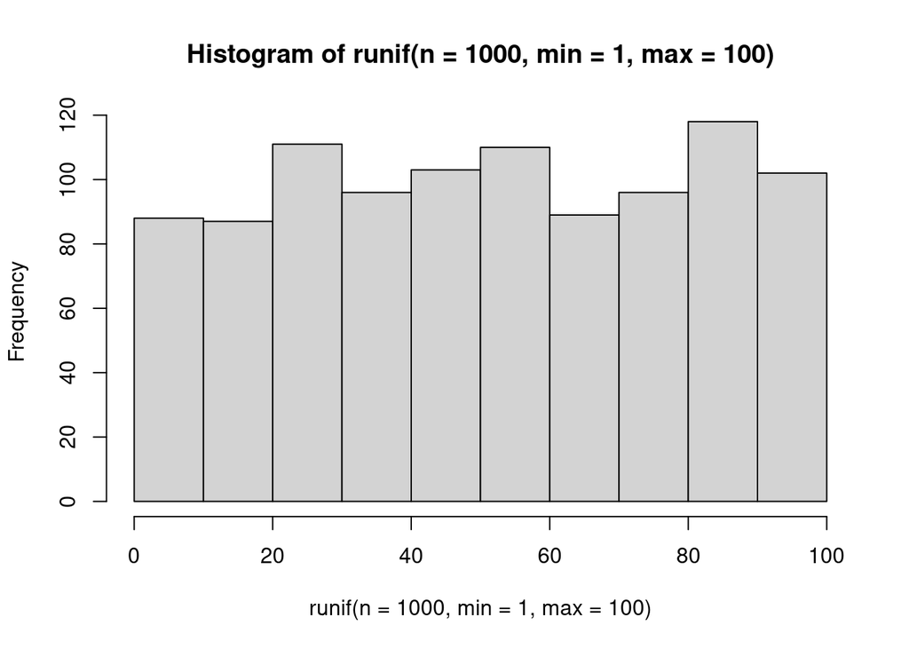

```r
# random number dist:
runif(n = 1000, min = 1, max = 100) |> hist()   # uniform distr sampling (continuous)
```

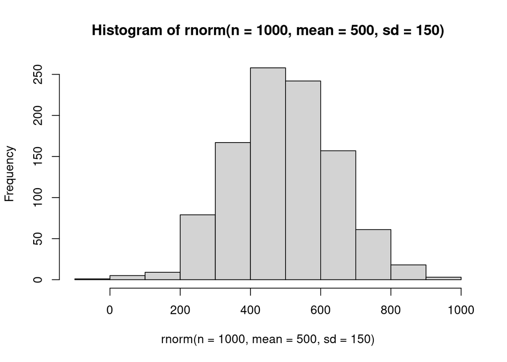

```r
rnorm(n = 1000, mean = 500, sd = 150) |> hist()   # normal distr sampling
```

##### Explicit vector coercion & augmented vectors

Vectors can also contain arbitrary additional metadata in the form of attributes. These attributes are used to create augmented vectors which build on additional behavior. For example, factors are built on top of integer vectors.

```r
vector_fct <- factor(vector_chr, levels = c("small", "medium", "large"))

typeof(vector_fct) # factor turns chr into integer vector
```

```
[1] "integer"
```

```r
attributes(vector_fct)
```

```
$levels
[1] "small"  "medium" "large"

$class
[1] "factor"
```

```r
as.integer(vector_fct)
```

```
[1] 3 1 2
```

### Create tibble / dataframe

```r
data_dictionary <- tibble(name = c("bin_id", "collection_date",
                                   "weekday", "location", "mass_VAR_kg"),
                          description = c("unique identifier of waste bin",
                                          "calendar date of waste collection",
                                          "corresponding weekday of collection",
                                          "location of waste bin in Zurich",
                                          "measured mass of waste of type VAR in kg (types: paper, plastic, glass, metal, organic,other)"))

tib_data <- tibble(
  vector_lgl,
  vector_int,
  vector_dbl,
  vector_chr,
  vector_fct,
  date = Sys.Date()  # adjusts length to other columns (has to be repeatable)
)
print(tib_data)
```

```
# A tibble: 3 × 6
  vector_lgl vector_int vector_dbl vector_chr vector_fct date
  <lgl>           <int>      <dbl> <chr>      <fct>      <date>
1 TRUE                1    1293    large      large      2024-06-12
2 FALSE               3       5.15 small      small      2024-06-12
3 NA                  6      90.5  medium     medium     2024-06-12
```

```r
tribble <- tribble(   # Create (small) tibbles using a row-by-row layout
  ~id,  ~bp1, ~bp2,
   "A",  100,  120,
   "B",  140,  115,
   "C",  120,  125
)
print(tribble)
```

```
# A tibble: 3 × 3
  id      bp1   bp2
  <chr> <dbl> <dbl>
1 A       100   120
2 B       140   115
3 C       120   125
```

Accessing a vector from a dataframe:

```r
tib_data |>
  pull(vector_fct)   # selects actual vector
```

```
[1] large  small  medium
Levels: small medium large
```

```r
tib_data$vector_fct  # selects actual vector
```

```
[1] large  small  medium
Levels: small medium large
```

```r
tib_data[5]          # using numeric index, returns actual column; access col 5
```

```
# A tibble: 3 × 1
  vector_fct
  <fct>
1 large
2 small
3 medium
```

```r
tib_data[[5]]        # selects actual vector; access values in col 5
```

```
[1] large  small  medium
Levels: small medium large
```

### Joining data frames

`<something>_join(x, y)`

- `left_join()`: all rows from x
- `right_join()`: all rows from y
- `full_join()`: all rows from both x and y

```r
x <- tribble(
  ~id, ~value_x,
  1,   "x1",
  2,   "x2",
  3,   "x3"
)

y <- tribble(
  ~id, ~value_y,
  1,   "y1",
  2,   "y2",
  4,   "y4"
)

left_join(x, y)
```

```
# A tibble: 3 × 3
     id value_x value_y
  <dbl> <chr>   <chr>
1     1 x1      y1
2     2 x2      y2
3     3 x3      <NA>
```

```r
right_join(y, x)
```

```
# A tibble: 3 × 3
     id value_y value_x
  <dbl> <chr>   <chr>
1     1 y1      x1
2     2 y2      x2
3     3 <NA>    x3
```

```r
right_join(x, y)
```

```
# A tibble: 3 × 3
     id value_x value_y
  <dbl> <chr>   <chr>
1     1 x1      y1
2     2 x2      y2
3     4 <NA>    y4
```

```r
full_join(x, y)
```

```
# A tibble: 4 × 3
     id value_x value_y
  <dbl> <chr>   <chr>
1     1 x1      y1
2     2 x2      y2
3     3 x3      <NA>
4     4 <NA>    y4
```

```r
full_join(y, x)
```

```
# A tibble: 4 × 3
     id value_y value_x
  <dbl> <chr>   <chr>
1     1 y1      x1
2     2 y2      x2
3     4 y4      <NA>
4     3 <NA>    x3
```

## Conditions

```r
waste_data |>
  mutate(collection_date  =  if_else(collection_date == "Sunday, 31st March 2024",
                                     "2024-03-31",
                                     "2024-04-04"))
```

```
# A tibble: 20 × 10
   bin_id collection_date location   mass_total_kg mass_paper_kg mass_plastic_kg
    <dbl> <chr>           <chr>              <dbl>         <dbl>           <dbl>
 1      1 2024-03-31      Baeckeran…            30             5               3
 2      2 2024-03-31      Baeckeran…            30            11               2
 3      3 2024-03-31      Baeckeran…            30             2               6
 4      4 2024-03-31      Baeckeran…            30             9               4
 5      5 2024-03-31      Baeckeran…            30             4               0
 6      6 2024-03-31      Landwiese             30             4               6
 7      7 2024-03-31      Landwiese             30             3               1
 8      8 2024-03-31      Landwiese             30             8               4
 9      9 2024-03-31      Landwiese             30             1              14
10     10 2024-03-31      Landwiese             30             2               5
11     11 2024-04-04      Baeckeran…            30             7               3
12     12 2024-04-04      Baeckeran…            30             3               7
13     13 2024-04-04      Baeckeran…            30             4               8
14     14 2024-04-04      Baeckeran…            30             9               3
15     15 2024-04-04      Baeckeran…            30             3               2
16     16 2024-04-04      Landwiese             30            10               2
17     17 2024-04-04      Landwiese             30             3               6
18     18 2024-04-04      Landwiese             30             6               4
19     19 2024-04-04      Landwiese             30             3               8
20     20 2024-04-04      Landwiese             30             4               8
# ℹ 4 more variables: mass_glass_kg <dbl>, mass_metal_kg <dbl>,
#   mass_organic_kg <dbl>, mass_other_kg <dbl>
```

```r
waste_gt |>
    mutate(income_cat = case_when(
        income_id == "HIC" ~ "high income",
        income_id == "UMC" ~ "upper-middle income",
        income_id == "LMC" ~ "lower-middle income",
        .default = income_id          #old way of writing: TRUE ~ col_name
    ))

sludge |>
    mutate(system = case_when(id == 6 ~ "septic tank",
                              .default = system))

survey |>
  mutate(across(starts_with("sep_"), ~ case_when(
    . == "Separated" ~ "s",          # dot is a placeholder for all selected cols
    . == "Not separated" ~ "ns",
    . == "No answer" ~ "noa"
  )))            # https://www.perplexity.ai/search/In-an-R-zSpzF9tWTUOpT8NO0PdLAA
```

## Programming with R

##### For loops

```r
size <- tib_data$vector_fct

for (s in size) {
  msg <- paste(
    "------", s, "------"
  )
  print(msg)
}
```

```
[1] "------ large ------"
[1] "------ small ------"
[1] "------ medium ------"
```

##### If statements

```r
pet <- c("bat", "cat", "dog", "bird", "horse")

for(p in pet) {
  if(p == "dog") {
    msg <- paste("A", p, "is the best!")
  } else {
    msg <- paste("A", p, "is okay I guess.")
  }
  print(msg)
}
```

```
[1] "A bat is okay I guess."
[1] "A cat is okay I guess."
[1] "A dog is the best!"
[1] "A bird is okay I guess."
[1] "A horse is okay I guess."
```

```r
sounds <- c(NA, "meow", "woof", "chirp", "neigh")

message <- list() #list is more versatile, can use index; alt: vector(length = 5)

for (i in seq_along(pet)) {
  if (pet[i] == "dog") {
    message[i] <- paste("The", pet[i], "goes", sounds[i])
  } else {
    message[i] <- paste("The", pet[i], "says", sounds[i])
  }
}
print(message)
```

```
[[1]]
[1] "The bat says NA"

[[2]]
[1] "The cat says meow"

[[3]]
[1] "The dog goes woof"

[[4]]
[1] "The bird says chirp"

[[5]]
[1] "The horse says neigh"
```

## Other functions

### Factors

```r
sanitation |>
  mutate(varname_short = factor(varname_short, levels = c("san_sm","san_bas",
                                                          "san_lim", "san_unimp",
                                                          "san_od"))) |>
  count(varname_short, varname_long)
```

```
# A tibble: 5 × 3
  varname_short varname_long                           n
  <fct>         <chr>                              <int>
1 san_sm        safely managed sanitation services 14742
2 san_bas       basic sanitation services          14742
3 san_lim       limited sanitation services        14742
4 san_unimp     unimproved sanitation facilities   14742
5 san_od        no sanitation facilities           14742
```

Any values not in the level will be silently converted to NA. (Might want to use [`forcats::fct()`](https://forcats.tidyverse.org/reference/fct.html) instead.)

Access the set of valid levels directly with [`levels()`](https://rdrr.io/r/base/levels.html). You can also create a factor when reading your data with readr with [`col_factor()`](https://readr.tidyverse.org/reference/parse_factor.html):  
`read_csv(csv, col_types = cols(month = col_factor(month_levels)))`

To reverse the order of the fct, s.t. the “first” item is on top of the y-axis on a figure use `fct_rev()` (https://www.perplexity.ai/search/When-using-ggplot-.9PkPLwERA2BJyVcRre66g)

```r
fig_avail_response |>
  ggplot(aes(x = avail_resp_short, y = fct_rev(waste_type))) +
  geom_tile(aes(fill = n)) +
  labs(x = "Availability",
       y = "Waste type",
       fill = "# students")
```

[`fct_reorder()`](https://forcats.tidyverse.org/reference/fct_reorder.html) takes three arguments:

- `.f`, the factor whose levels you want to modify.
- `.x`, a numeric vector that you want to use to reorder the levels.
- Optionally, `.fun`, a function that’s used if there are multiple values of `.x` for each value of `.f`. The default value is `median`.

[`fct_relevel()`](https://forcats.tidyverse.org/reference/fct_relevel.html) takes a factor, `.f`, and then any number of levels that you want to move to the front of the line.

Further functions: https://r4ds.hadley.nz/factors

`fct_reorder2(.f, .x, .y)`, [`fct_infreq()`](https://forcats.tidyverse.org/reference/fct_inorder.html) (+[`fct_rev()`](https://forcats.tidyverse.org/reference/fct_rev.html)), [`fct_recode()`](https://forcats.tidyverse.org/reference/fct_recode.html),`fct_lump_*()`, [`ordered()`](https://rdrr.io/r/base/factor.html)

### Dates

In R and other programming languages, dates are stored as numbers. The number of days since 1970-01-01 is the ISO 8601 standard.

In Excel, dates are stored as numbers of days since 1900-01-01. In Excel, the date number 1 corresponds to “1900-01-01,” but this system incorrectly considers 1900 as a leap year, which it is not. As a result, to correctly interpret date numbers that originate from systems like Excel, the origin “1899-12-30” is used to account for this discrepancy

```r
dates <- read_excel(here::here("data/raw/date-formats.xlsx"))

head(dates)
```

```
# A tibble: 1 × 5
  date_iso   date_us    date_eu    date_num date_time
  <chr>      <chr>      <chr>         <dbl> <dttm>
1 2023-11-01 11/01/2023 01/11/2023    45231 2023-11-01 00:00:00
```

```r
dates_class <- dates |>
    mutate(date_iso = as_date(date_iso)) |>
    mutate(date_us = mdy(date_us)) |> #mdy: month, day, year
    mutate(date_eu = dmy(date_eu)) |>
    mutate(date_num = as_date(date_num, origin = "1899-12-30")) |>
    mutate(date = as_date(date_time)) |>
    mutate(date_time_tz = with_tz(date_time, tzone = "Africa/Kampala")) |> #forece_tz  to apply local time zone
    mutate(today = today())

print(dates_class)
```

```
# A tibble: 1 × 8
  date_iso   date_us    date_eu    date_num   date_time           date
  <date>     <date>     <date>     <date>     <dttm>              <date>
1 2023-11-01 2023-11-01 2023-11-01 2023-11-01 2023-11-01 00:00:00 2023-11-01
# ℹ 2 more variables: date_time_tz <dttm>, today <date>
```

```r
as.numeric(today())
```

```
[1] 19886
```

```r
as_date(1)
```

```
[1] "1970-01-02"
```

```r
dates_class |>
    select(today) |>
    mutate(year = year(today)) |>
    #mutate(month = month(today, label = TRUE, abbr = FALSE, locale = "fr_FR")) |>
    mutate(quarter = quarter(today)) |>
    mutate(week = week(today)) |>
    mutate(day = day(today)) |>
    #mutate(day_of_week = wday(today, label = TRUE, abbr = FALSE, locale = "fr_FR")) |>
    mutate(day_of_year = yday(today)) |>
    mutate(week_of_year = week(today))
```

```
# A tibble: 1 × 7
  today       year quarter  week   day day_of_year week_of_year
  <date>     <dbl>   <int> <dbl> <int>       <dbl>        <dbl>
1 2024-06-12  2024       2    24    12         164           24
```

`OlsonNames()`: List of tz database time zones

### Others

Integer division `%/%`, modulo `%%`

```r
# objects
letters
```

```
 [1] "a" "b" "c" "d" "e" "f" "g" "h" "i" "j" "k" "l" "m" "n" "o" "p" "q" "r" "s"
[20] "t" "u" "v" "w" "x" "y" "z"
```

```r
LETTERS
```

```
 [1] "A" "B" "C" "D" "E" "F" "G" "H" "I" "J" "K" "L" "M" "N" "O" "P" "Q" "R" "S"
[20] "T" "U" "V" "W" "X" "Y" "Z"
```

#### Selection / Detection

`select()` and others https://dplyr.tidyverse.org/reference/select.html  
`starts_with("<e.g. a string>")` https://tidyselect.r-lib.org/reference/starts_with.html  
`str_detect()` [Difference btw. str_detect and contains](https://www.perplexity.ai/search/In-R-what-ufgJsafzSMGNnfe721WmzQ)

```r
# str_detect()
survey |>
 mutate(gender_new = case_when(
 gender == "Male" ~ "M",
 str_detect(gender, pattern = "ema") == TRUE ~ "F",
 str_detect(gender, pattern = "bin") == TRUE ~ NA_character_,
 TRUE ~ gender
 ), .before = gender)
```

```
# A tibble: 15 × 20
      id time_stamp          consent age   gender_new gender    people_household
   <int> <dttm>              <chr>   <fct> <chr>      <chr>     <fct>
 1     1 2024-03-20 08:37:09 Given   >29   M          Male      4 people
 2     2 2024-03-21 15:16:53 Given   22-25 F          Female    2 people
 3     3 2024-03-21 15:24:27 Given   26-29 M          Male      2 people
 4     4 2024-03-21 15:34:44 Given   22-25 M          Male      5 people
 5     5 2024-03-21 15:35:08 Given   >29   M          Male      2 people
 6     6 2024-03-21 17:48:17 Denied  <NA>  <NA>       <NA>      <NA>
 7     7 2024-03-21 17:50:23 Given   <18   <NA>       Non-bina… 1 person
 8     8 2024-03-21 18:14:25 Given   22-25 F          Female    6 or more people
 9     9 2024-03-21 18:47:23 Given   >29   <NA>       Non-bina… 6 or more people
10    10 2024-03-21 18:46:21 Given   22-25 F          Female    2 people
11    11 2024-03-21 18:48:34 Given   18-21 M          Male      2 people
12    12 2024-03-21 18:49:17 Given   26-29 F          Female    4 people
13    13 2024-03-22 13:49:34 Given   26-29 M          Male      4 people
14    14 2024-03-22 15:07:28 Given   22-25 F          Female    2 people
15    15 2024-03-24 14:22:23 Given   18-21 M          Male      6 or more people
# ℹ 13 more variables: degree <chr>, field_of_study <chr>, sep_paper <chr>,
#   sep_cardboard <chr>, sep_plastic <chr>, sep_glass <chr>, sep_metal <chr>,
#   sep_organic <chr>, sep_vegioil <chr>, sep_electro <chr>,
#   grocery_waste <dbl>, study_to_waste <dbl>, suggest_improve <chr>
```

```r
# long names can be saved to a variable
long_col_name <- "field_of_study"

count(survey, !!sym(long_col_name)) # !!sym() converts the variable long_col_name into symbol usable in str_detect() function https://www.perplexity.ai/search/Using-the-filter-EamBK_pYRmucZrXnpBhYDQ
```

```
# A tibble: 7 × 2
  field_of_study                                n
  <chr>                                     <int>
1 Architecture and Civil Engineering            1
2 Engineering Sciences                          7
3 Humanities, Political and Social Sciences     1
4 Natural Sciences and Mathematics              3
5 Others                                        1
6 Prefer not to say.                            1
7 <NA>                                          1
```

## Visualization - Graphs

Save figures to files in code: `ggsave()` –> when searching for figure, the code is also returned!

### Aesthetic mappings

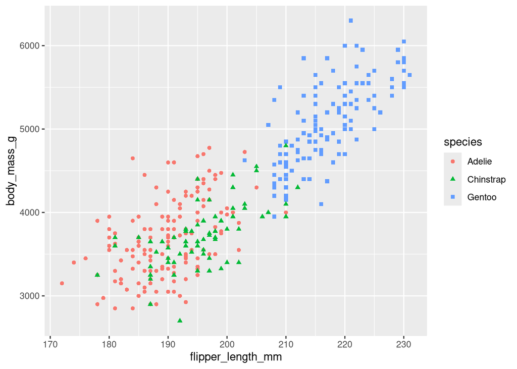

```r
ggplot(data = penguins,
       mapping = aes(x = flipper_length_mm,
                     y = body_mass_g,
                     color = species,
                     shape = species)) +
  geom_point() # na.rm = TRUE can be included in the geom settings
```

### Settings

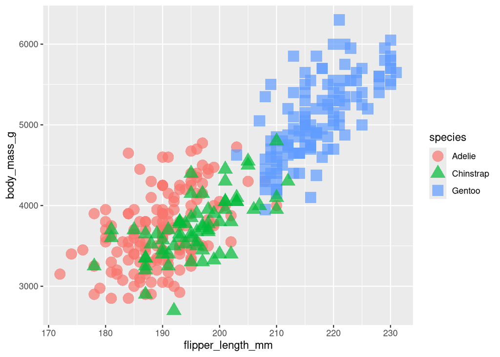

```r
ggplot(data = penguins,
       mapping = aes(x = flipper_length_mm,
                     y = body_mass_g,
                     color = species,
                     shape = species)) +
  geom_point(size = 5, alpha = 0.7)
```

### Color scales

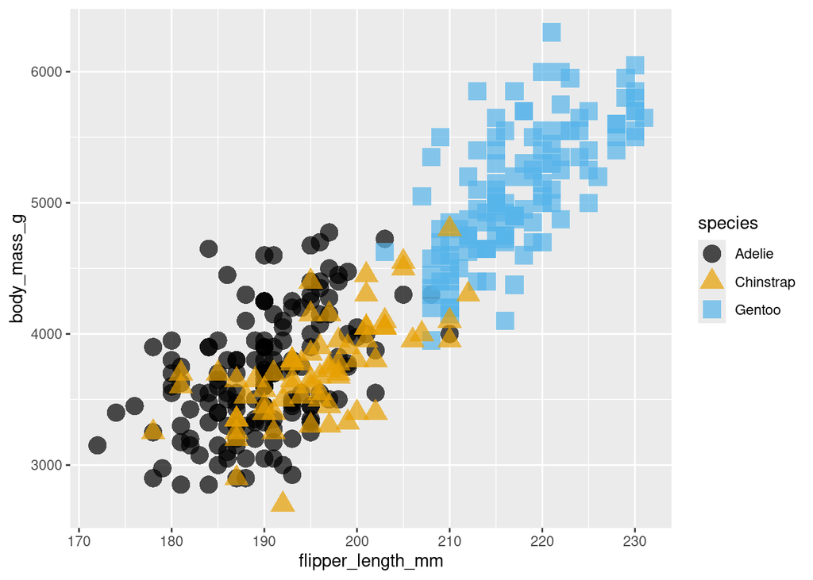

```r
ggplot(data = penguins,
       mapping = aes(x = flipper_length_mm,
                     y = body_mass_g,
                     color = species,
                     shape = species)) +
  geom_point(size = 5, alpha = 0.7) +
  scale_color_colorblind()
```

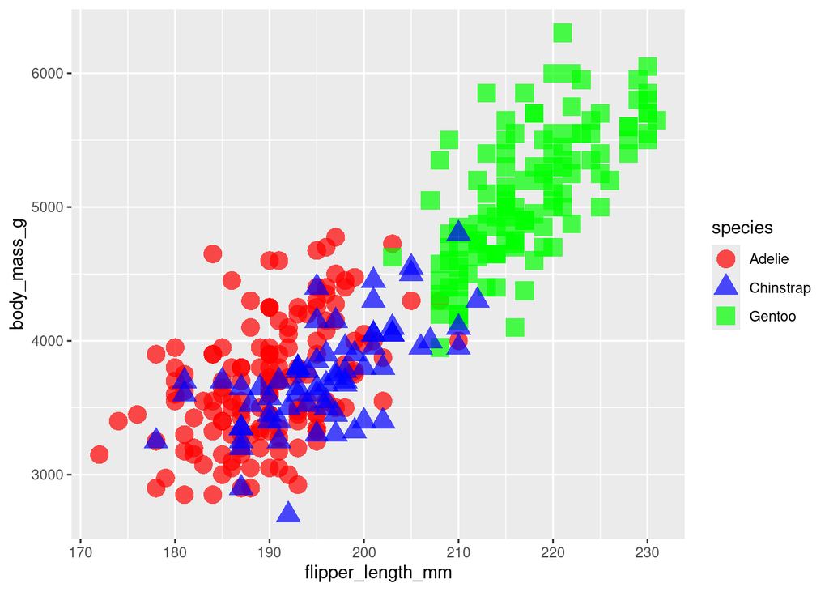

```r
# similar for other mappings; e.g., scale_fill_manual(values = c("red", "orange", "grey")
ggplot(data = penguins,
       mapping = aes(x = flipper_length_mm,
                     y = body_mass_g,
                     color = species,
                     shape = species)) +
  geom_point(size = 5, alpha = 0.7) +
  scale_color_manual(values = c("red", "blue", "green"))
```

### Facets

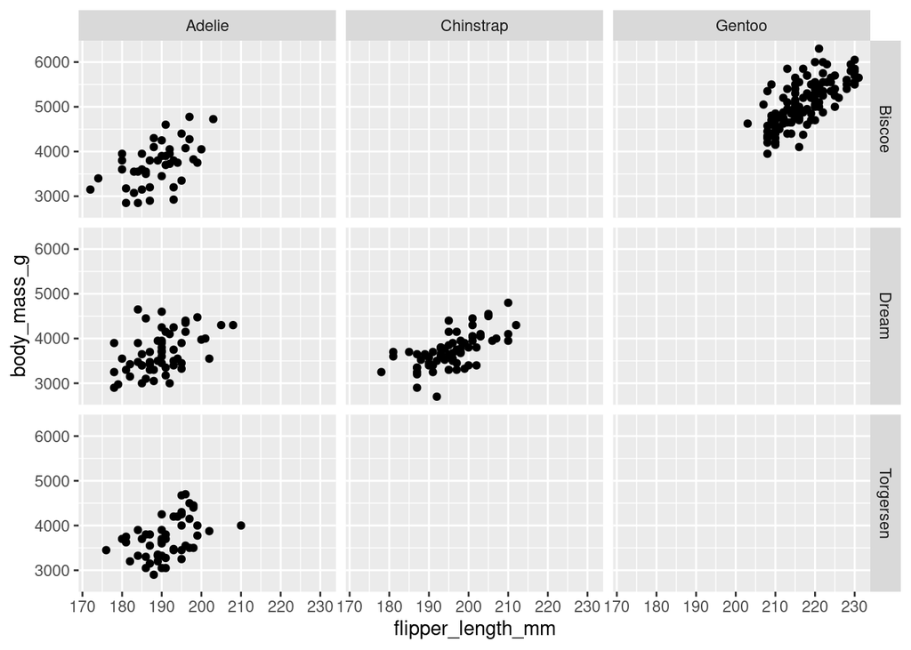

```r
ggplot(data = penguins,
       mapping = aes(x = flipper_length_mm,
                     y = body_mass_g)) +
  geom_point() +
  facet_grid(island ~ species)
```

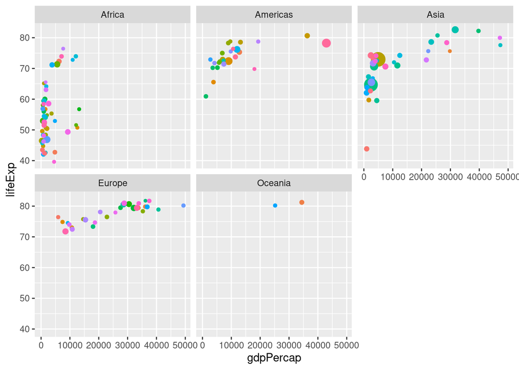

```r
ggplot(data = filter(gapminder, year == 2007),
       mapping = aes(x = gdpPercap,
                     y = lifeExp,
                     size = pop,
                     color = country)) +
  geom_point(show.legend = FALSE) +
  facet_wrap(~continent)
```

### Themes

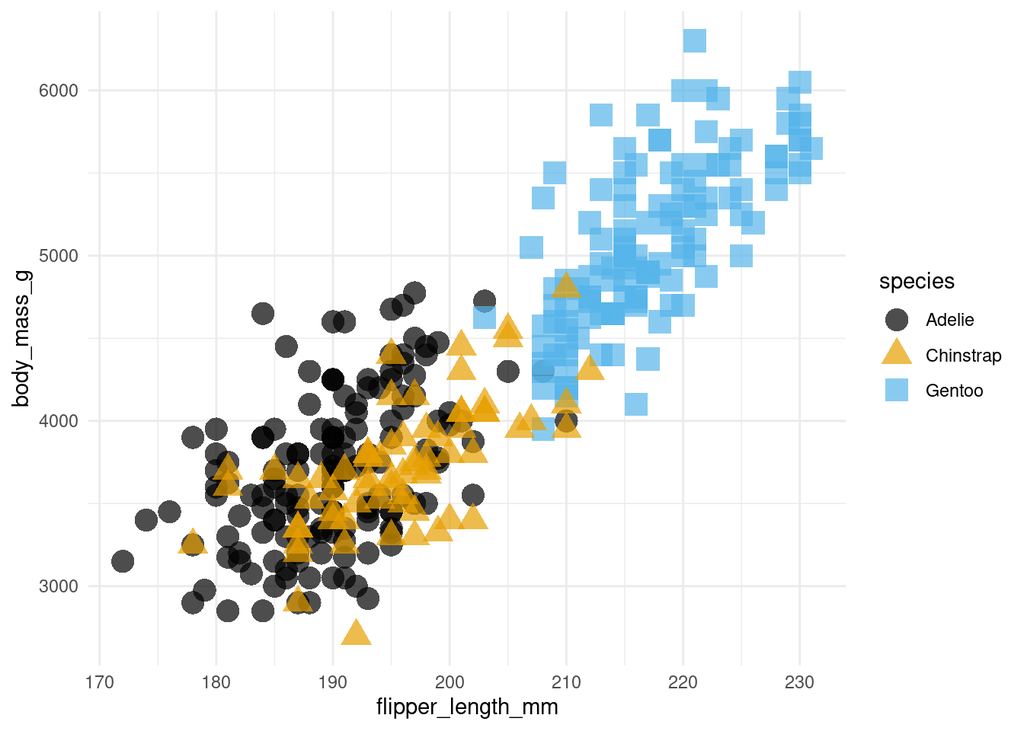

```r
ggplot(data = penguins,
       mapping = aes(x = flipper_length_mm,
                     y = body_mass_g,
                     color = species,
                     shape = species)) +
  geom_point(size = 5, alpha = 0.7) +
  scale_color_colorblind() +
  theme_minimal()
```

### Visualization Distribution

[Visualizing covariation](https://r4ds.hadley.nz/eda#covariation) of

- categorical & numerical variables: `geom_freqpoly()` or `geom_boxplot()`
- two categorical variables: `geom_tiles()` or `geom_count()`
- two numerical variables: `geom_point()` with transparency `alpha = 1/...` for large datasets; for very large datasets use `geom_bin2d()` or `geom_hex()` ; or bin one continuous variable s.t. it acts as categorical

#### Categorical variables

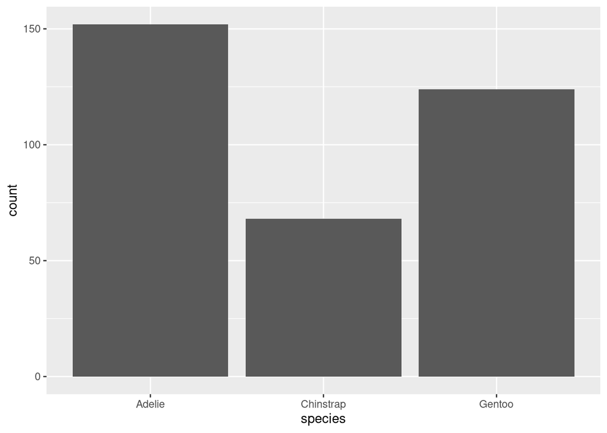

```r
ggplot(data = penguins,
       mapping = aes(x = species)) +
  geom_bar()
```

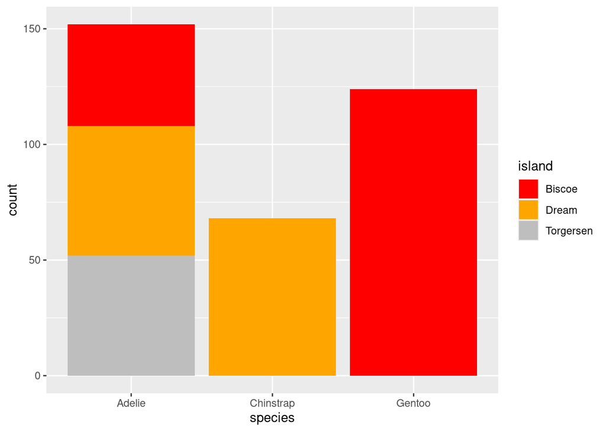

```r
ggplot(data = penguins,
       mapping = aes(x = species,
                     fill = island)) +
  geom_bar() +
  scale_fill_manual(values = c("red", "orange", "grey"))
```

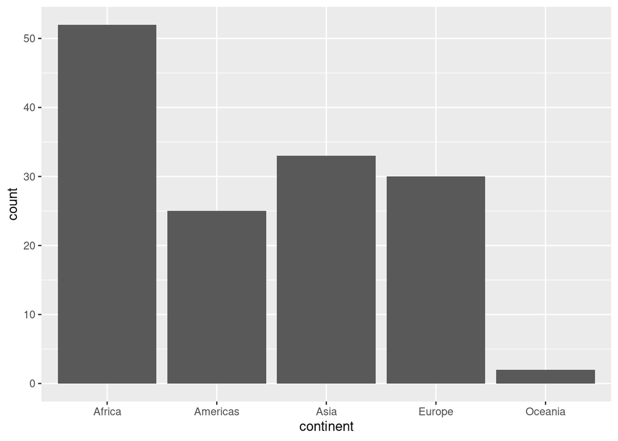

```r
ggplot(data = summarize(group_by(filter(gapminder, year == 2007), continent),
                        count = n(),
                        lifeExp = median(lifeExp)),
       mapping = aes(x = continent,
                     y = count)) +
  geom_col()
```

Visualizing covariation of two categorical variables

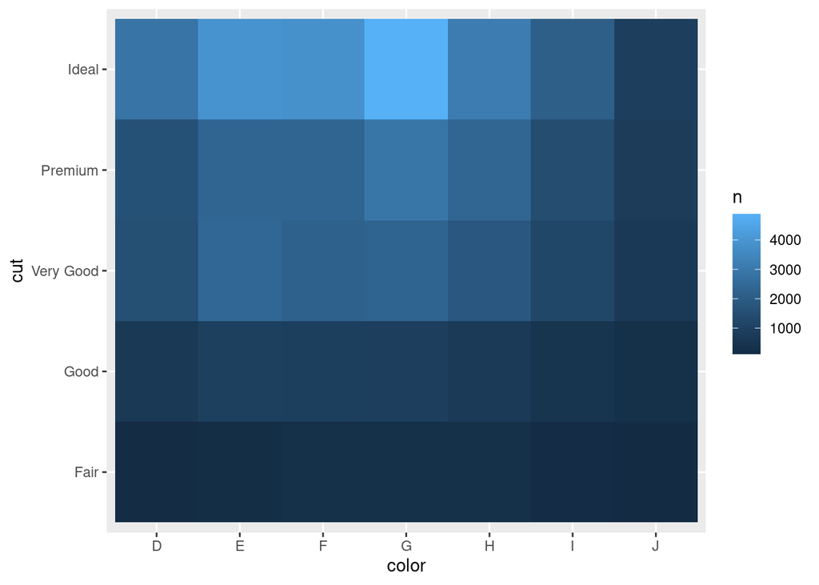

```r
diamonds |>
  count(color, cut) |>
  ggplot(aes(x = color, y = cut)) +
  geom_tile(aes(fill = n))
```

#### Numerical variables

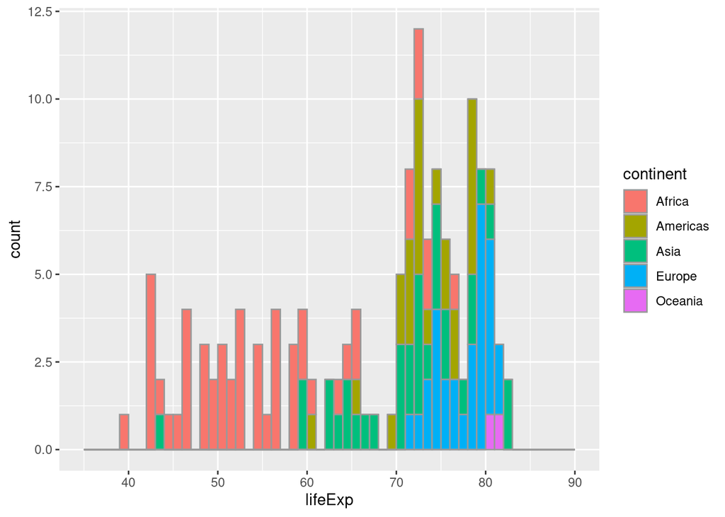

```r
ggplot(data = filter(gapminder, year == 2007),
       mapping = aes(x = lifeExp,
                     fill = continent)) +
  geom_histogram(col = "grey60", breaks = seq(35, 90, 1))
```

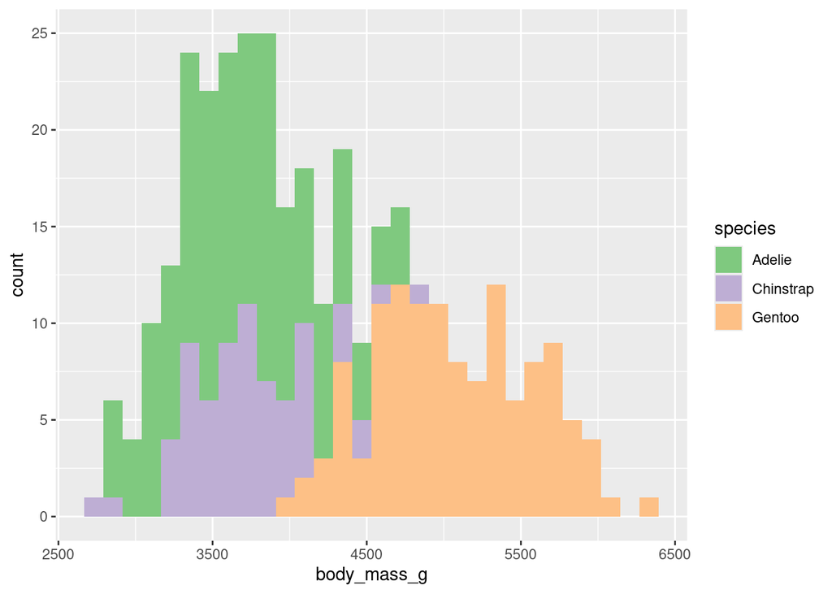

```r
ggplot(data = penguins,
       mapping = aes(x = body_mass_g,
                     fill = species)) +
  geom_histogram() +
  scale_fill_brewer(type = "qual")
```

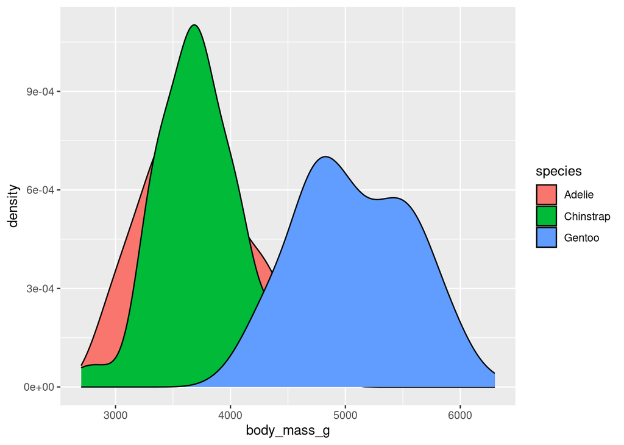

```r
ggplot(data = penguins,
       mapping = aes(x = body_mass_g,
                     fill = species)) +
  geom_density()
```

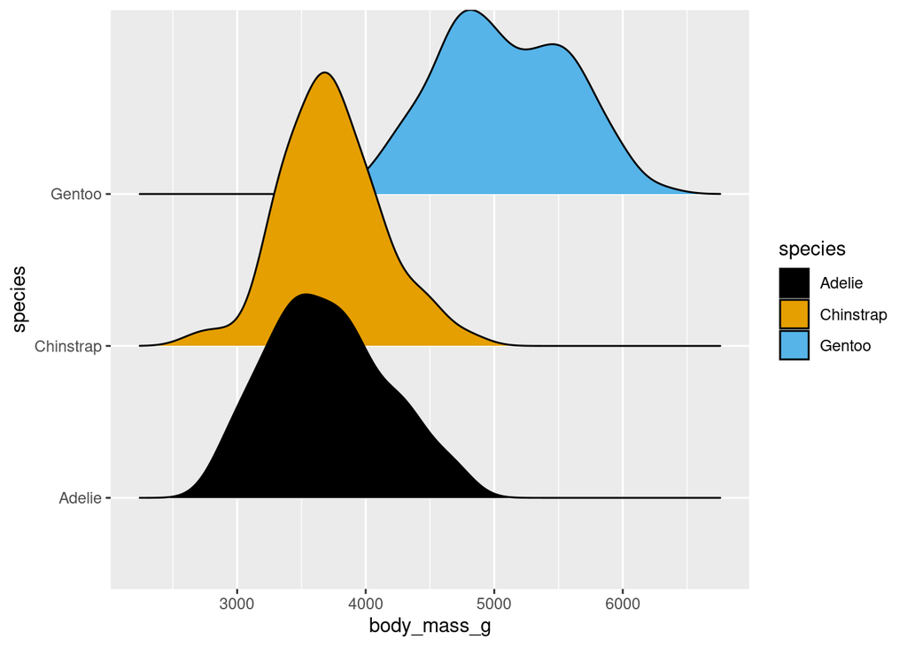

```r
ggplot(data = penguins,
       mapping = aes(x = body_mass_g,
                     y = species,
                     fill = species)) +
  geom_density_ridges() +
  scale_fill_colorblind()
```

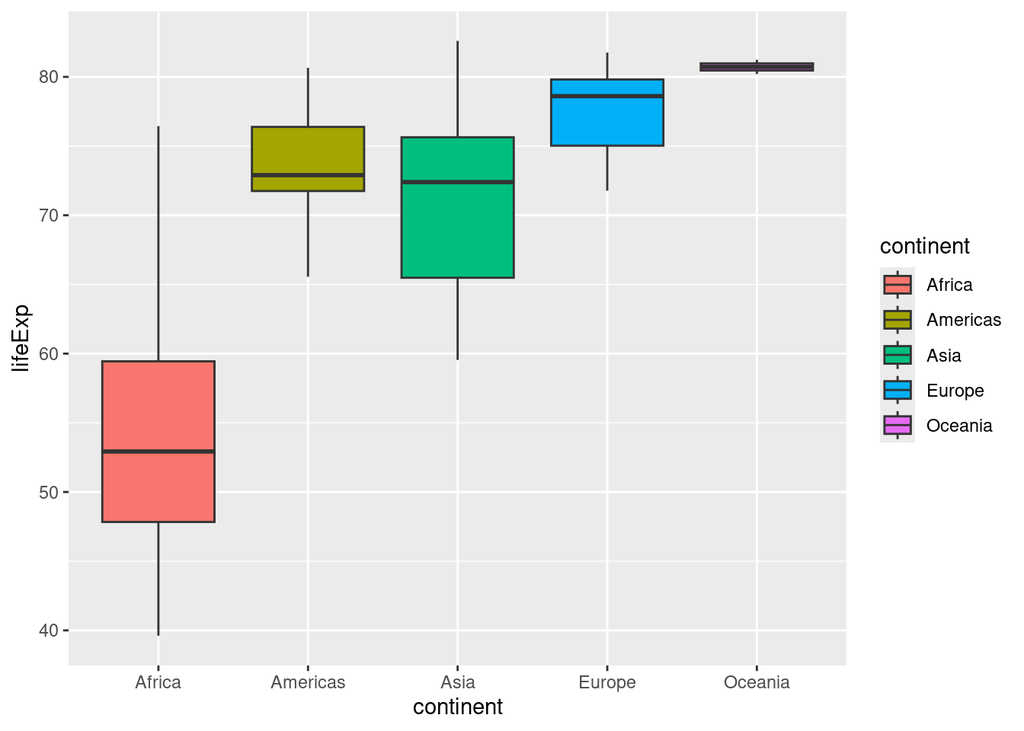

```r
ggplot(data = filter(gapminder, year == 2007),
       mapping = aes(x = continent,
                     y = lifeExp,
                     fill = continent)) +
  geom_boxplot(outlier.shape = NA)
```

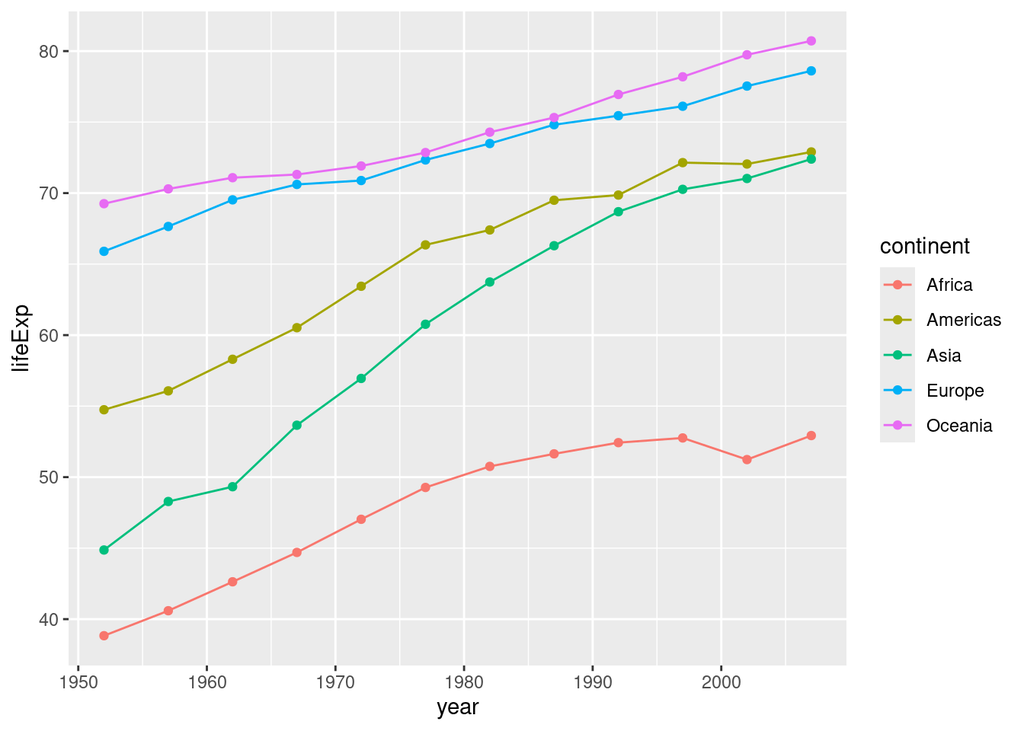

```r
ggplot(data = summarize(group_by(gapminder, continent, year),
                        lifeExp = median(lifeExp)),
       mapping = aes(x = year,
                     y = lifeExp,
                     color = continent)) +
  geom_line() +
  geom_point()
```

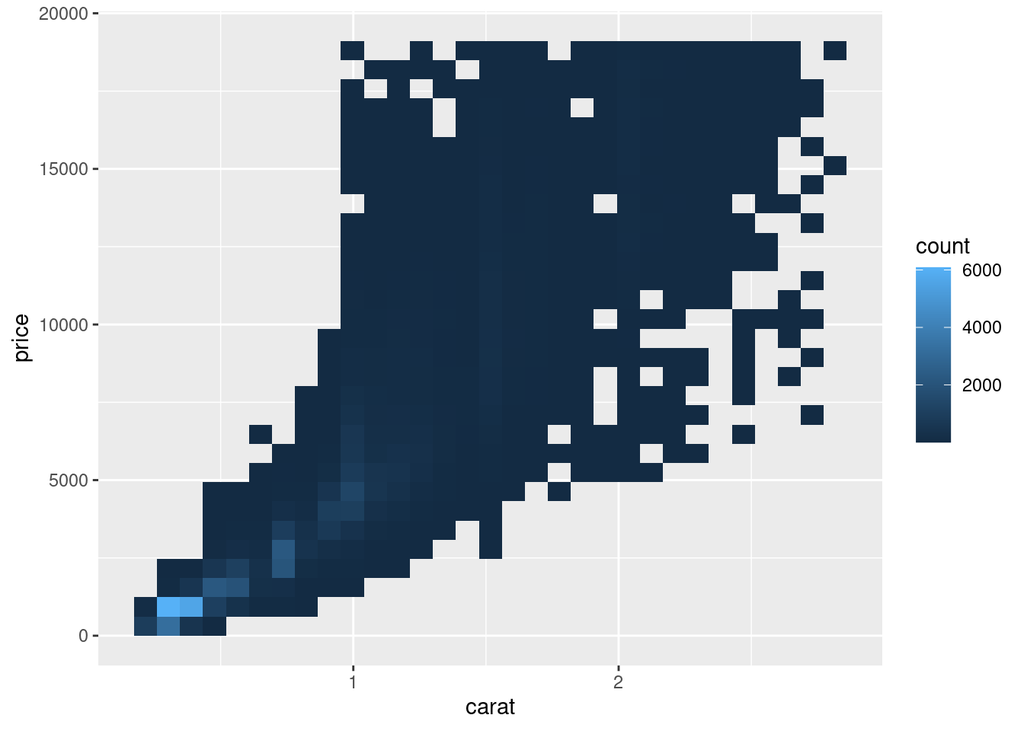

```r
ggplot(filter(diamonds, carat < 3), aes(x = carat, y = price)) +
  geom_bin2d()
```

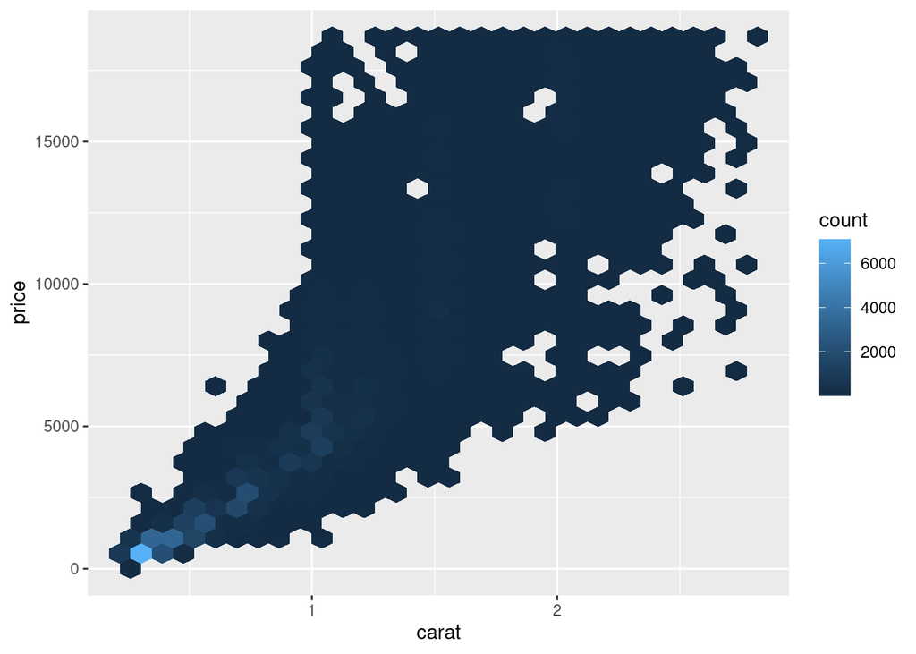

```r
# install.packages("hexbin")
ggplot(filter(diamonds, carat < 3), aes(x = carat, y = price)) +
  geom_hex()
```

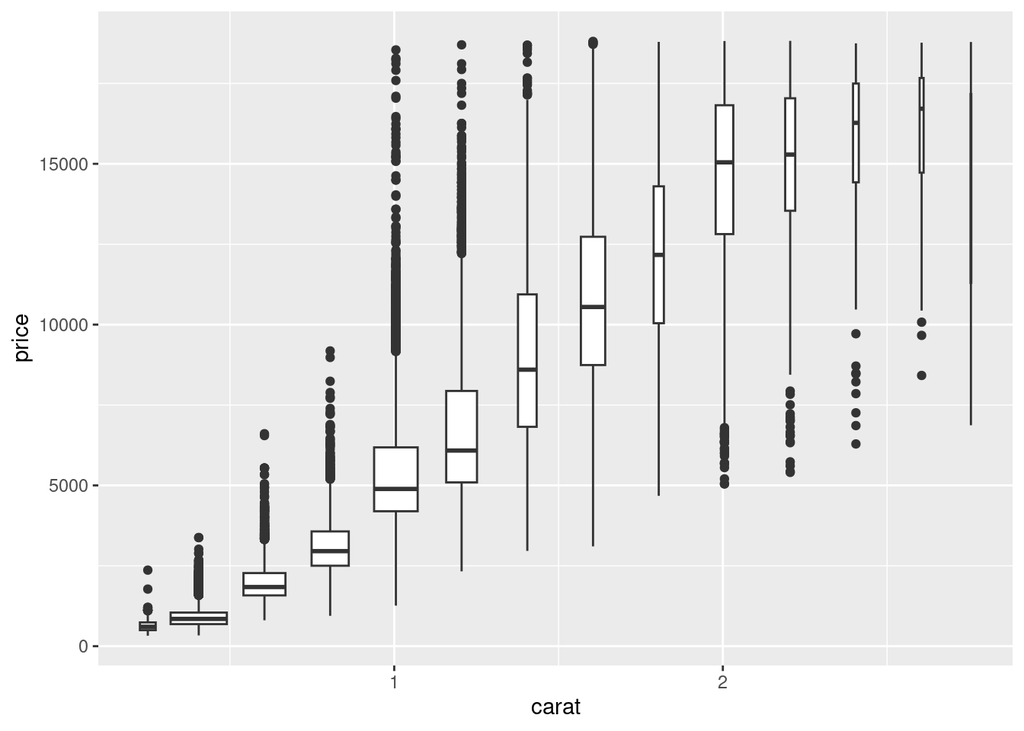

```r
ggplot(filter(diamonds, carat < 3), aes(x = carat, y = price)) +
  geom_boxplot(aes(group = cut_width(carat, 0.2)),
               varwidth = TRUE) # visualize nr of observations
```

### Examples

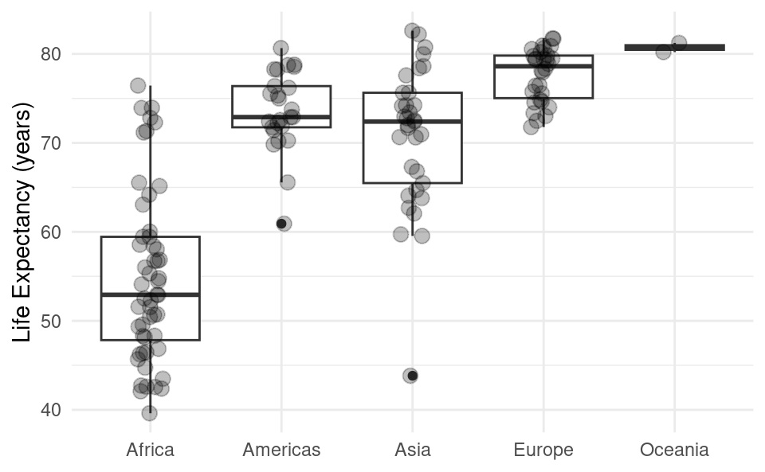

```r
ggplot(data = filter(gapminder,
                     year == 2007),
       mapping = aes(x = continent,
                     y = lifeExp)) +
  geom_boxplot() +
  geom_jitter(width = 0.1, alpha = 1/4, size = 3) +
  labs(x = NULL,
       y = "Life Expectancy (years)") +
  theme_minimal() # + geom_smooth(method = "METHOD")
```

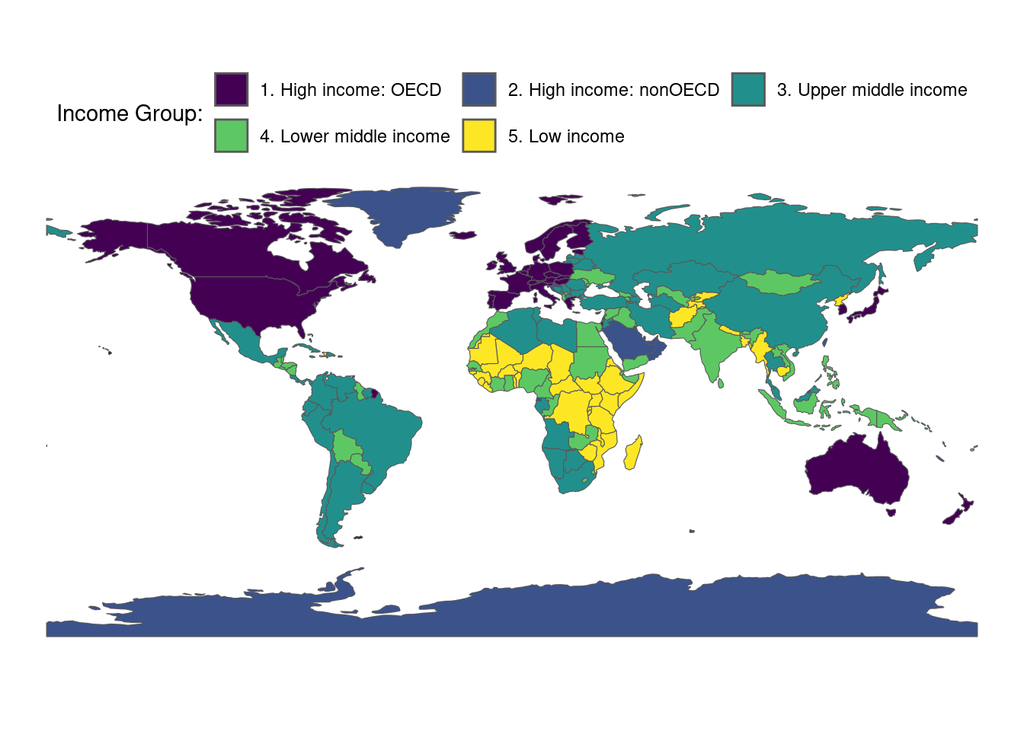

```r
world <- ne_countries(scale = "small", returnclass = "sf")

world |>
  mutate(income_grp = factor(income_grp, ordered = T)) |>
  ggplot(aes(fill = income_grp)) +
  geom_sf() +
  theme_void() +
  theme(legend.position = "top") +
  labs(fill = "Income Group:") +
  guides(fill = guide_legend(nrow = 2, byrow = TRUE))
```

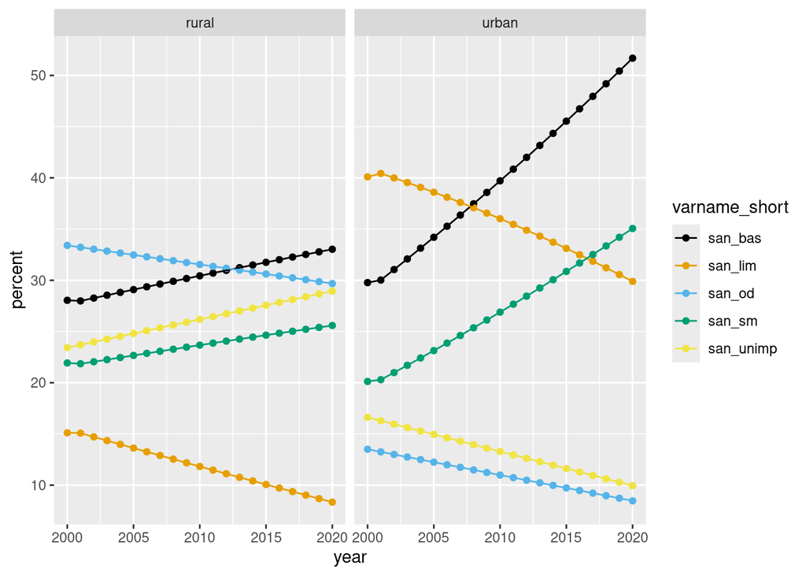

```r
ggplot(filter(sanitation,
              name == "Nigeria", (residence == "rural" | residence == "urban")),
       aes(year,
           percent,
           group = varname_short,
           color = varname_short)) +
  geom_point() +
  geom_line() +
  facet_wrap(~residence) +
  scale_color_colorblind()
```

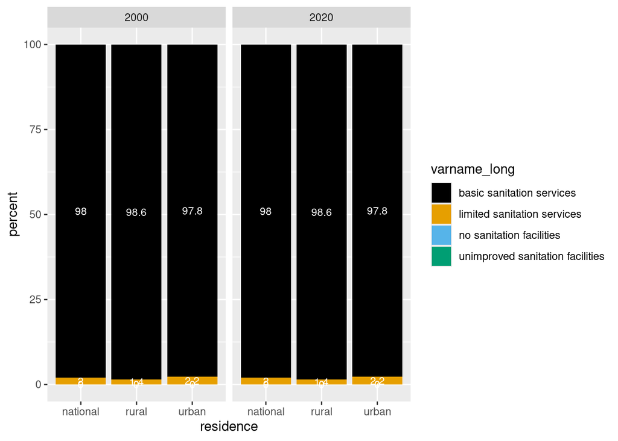

```r
ggplot(filter(sanitation,
              name == "Hungary",
              year  %in% c(2000, 2020),
              varname_short != "san_sm"),
       aes(residence, percent, fill = varname_long)) +
  geom_col()+
  scale_fill_colorblind() +
  facet_wrap(~year) +
  geom_text(aes(label = round(percent, 1)),
          position = position_stack(vjust = 0.5),
          size = 3,
          color = "white")
```